# Homelessness

Haley Uyeunten

## Introduction

The 2020 [point-in-time count](https://www.kingcounty.gov/elected/executive/constantine/news/release/2020/July/01-homeless-count.aspx) of people experiencing homelessness for Seattle/King County was 11,751. This represents a 5% increase over the 2019 count and reflects similar trend across many counties in the western U.S. A step towards addressing homelessness is improving our understanding of the relationship between local housing market factors and homelessness.

The U.S. Department of Housing and Urban Development (HUD) produced a report in 2019 [Market Predictors of Homelessness](https://www.huduser.gov/portal/sites/default/files/pdf/Market-Predictors-of-Homelessness.pdf) that describes a model-based approach to understanding of the relationship between local housing market factors, policies, demographics, climate and homelessness. Our project is motivated by the goals of the HUD study:

“To continue progressing toward the goals of ending and preventing homelessness, we must further our knowledge of the basic community-level determinants of homelessness. The primary objectives of this study are to (1) identify market factors that have established effects on homelessness, (2) construct and evaluate empirical models of community-level homelessness..”

We will investigate whether there are alternative modeling approaches that outperform the models described in the HUD report.

We want to specifically look at which HUD variables are best at predicting homeless rates. The HUD report includes predictors that have to do with the housing market, economy, local safety nets, and climate, as well as demographic and identifier variables.

## Data Collection

The data for this project are described in HUD’s report [Market Predictors of Homelessness](https://www.huduser.gov/portal/sites/default/files/pdf/Market-Predictors-of-Homelessness.pdf) in the section titled DATA.

I will refer you to this section of the HUD report for a detailed description of the sources of the data and how they were processed.

### Load necessary packages

```r
#skimr provides a nice summary of a data set
library(skimr)
#leaps will be used for model selection
library(leaps)
#readxl lets us read Excel files
library(readxl)
#GGally has a nice pairs plotting function
library(GGally)
#corrplot has nice plots for correlation matrices
library(corrplot)
#gridExtra
library(gridExtra)
#glmnet is used to fit glm's. It will be used for lasso and ridge regression models.
library(glmnet)
#tidymodels has a nice workflow for many models. We will use it for XGBoost
library(tidymodels)
#xgboost lets us fit XGBoost models
library(xgboost)
#vip is used to visualize the importance of predicts in XGBoost models
library(vip)
#tidyverse contains packages we will use for processing and plotting data
library(tidyverse)
#Set the plotting theme
theme_set(theme_bw())
```

### Examine the data dictionary

The data dictionary `HUD TO3 - 05b Analysis File - Data Dictionary.xlsx` contains descriptions of all variables in the data set.

$\rightarrow$ Load the data dictionary (call it `dictionary`) and view its contents using the function `View`.

```r
dictionary <- read_xlsx("HUD TO3 - 05b Analysis File - Data Dictionary.xlsx")
view(dictionary)
```

#### What are the sources of data?

$\rightarrow$ Use the dictionary to find the unique sources of data that are not derived from other variables. We will assume that derived variables are either have `Derived` equal to `No` or `Source or Root Variable` starts with the string `See`.

**Show Coding Hint**

You can use the `str_detect` function to determine whether a string includes particular string as a component.

```r
dictionary %>%
  filter(Derived == "No" & str_detect(`Source or Root Variable`, "See") == FALSE) %>%
  select(`Source or Root Variable`) %>%
  unique()
```

```
## # A tibble: 26 x 1
##    `Source or Root Variable`
##    <chr>
##  1 HUD
##  2 HUD PIT
##  3 HUD System Performance Measures
##  4 HUD CoC Funding Reports
##  5 HUD HIC
##  6 Census Intercensal Population Estimates
##  7 Census ACS 5-Year Estimates
##  8 Federal Housing Finance Agency
##  9 BLS Local Area Unemployment Statistics (LAUS)
## 10 Census (County Area in Sq. Miles)
## # ... with 16 more rows
```

What are the sources of most of the data?

$\rightarrow$ Make a bar graph of the counts of different data sources described in `Source or Root Variable`. Your graph should have the following features:

1. Order the bars in descending order based on the count.
2. Only include the 10 most common data sources.
3. Orient the plot so that it is easy to read the labels.

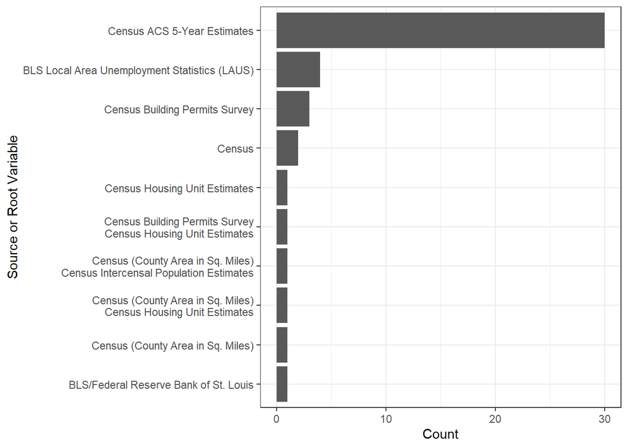

```r
dictionary %>%
  count(`Source or Root Variable`) %>%
  mutate(`Source or Root Variable` = fct_reorder(`Source or Root Variable`, n)) %>%
  head(10) %>%
  ggplot(aes(x = `Source or Root Variable`, y = n)) +
  geom_col() +
  coord_flip() +
  labs(x = "Source or Root Variable", y = "Count")
```

$\rightarrow$ What are the different Associated Domains of the variables?

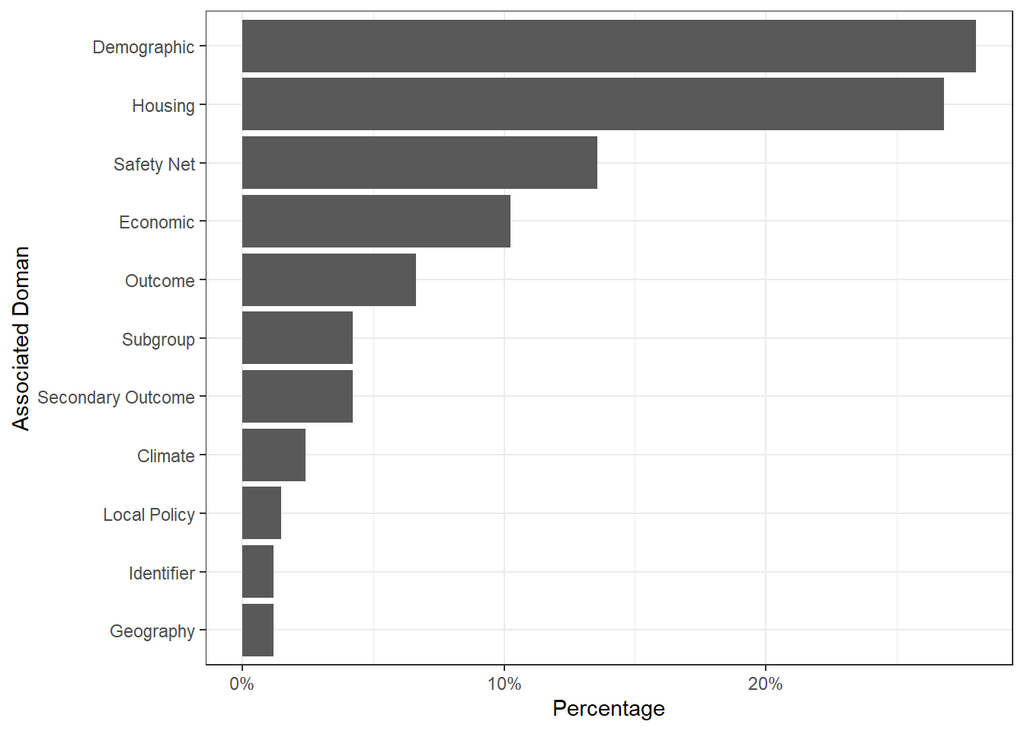

```r
dictionary %>%
  count(`Associated Domain`) %>%
  mutate(`Associated Domain` = fct_reorder(`Associated Domain`, n)) %>%
  ggplot(aes(x = `Associated Domain`, y = n/sum(n))) +
  geom_col() +
  coord_flip() +
  scale_y_continuous(labels = scales::percent) +
  labs(x = "Associated Doman", y = "Percentage")
```

Most of the variables are demographic and housing variables. Some of them are also related to safety nets, economics, and outcomes.

A big part of this project will be figuring out what variables to include in the analysis.

### Data ethics

#### Data Science Ethics Checklist

**A. Problem Formulation**

- **A.1 Well-Posed Problem**: Is it possible to answer our question with data? Is the problem well-posed?

**B. Data Collection**

- **B.1 Informed consent**: If there are human subjects, have they given informed consent, where subjects affirmatively opt-in and have a clear understanding of the data uses to which they consent?
- **B.2 Collection bias**: Have we considered sources of bias that could be introduced during data collection and survey design and taken steps to mitigate those?
- **B.3 Limit PII exposure**: Have we considered ways to minimize exposure of personally identifiable information (PII) for example through anonymization or not collecting information that isn’t relevant for analysis?
- **B.4 Downstream bias mitigation**: Have we considered ways to enable testing downstream results for biased outcomes (e.g., collecting data on protected group status like race or gender)?

**C. Data Storage**

- **C.1 Data security**: Do we have a plan to protect and secure data (e.g., encryption at rest and in transit, access controls on internal users and third parties, access logs, and up-to-date software)?
- **C.2 Right to be forgotten**: Do we have a mechanism through which an individual can request their personal information be removed?
- **C.3 Data retention plan**: Is there a schedule or plan to delete the data after it is no longer needed?

**D. Analysis**

- **D.1 Missing perspectives**: Have we sought to address blindspots in the analysis through engagement with relevant stakeholders (e.g., checking assumptions and discussing implications with affected communities and subject matter experts)?
- **D.2 Dataset bias**: Have we examined the data for possible sources of bias and taken steps to mitigate or address these biases (e.g., stereotype perpetuation, confirmation bias, imbalanced classes, or omitted confounding variables)?
- **D.3 Honest representation**: Are our visualizations, summary statistics, and reports designed to honestly represent the underlying data?
- **D.4 Privacy in analysis**: Have we ensured that data with PII are not used or displayed unless necessary for the analysis?
- **D.5 Auditability**: Is the process of generating the analysis well documented and reproducible if we discover issues in the future?

**E. Modeling**

- **E.1 Proxy discrimination**: Have we ensured that the model does not rely on variables or proxies for variables that are unfairly discriminatory?
- **E.2 Fairness across groups**: Have we tested model results for fairness with respect to different affected groups (e.g., tested for disparate error rates)?
- **E.3 Metric selection**: Have we considered the effects of optimizing for our defined metrics and considered additional metrics?
- **E.4 Explainability**: Can we explain in understandable terms a decision the model made in cases where a justification is needed?
- **E.5 Communicate bias**: Have we communicated the shortcomings, limitations, and biases of the model to relevant stakeholders in ways that can be generally understood?

**F. Deployment**

- **F.1 Redress**: Have we discussed with our organization a plan for response if users are harmed by the results (e.g., how does the data science team evaluate these cases and update analysis and models to prevent future harm)?
- **F.2 Roll back**: Is there a way to turn off or roll back the model in production if necessary?
- **F.3 Concept drift**: Do we test and monitor for concept drift to ensure the model remains fair over time?
- **F.4 Unintended use**: Have we taken steps to identify and prevent unintended uses and abuse of the model and do we have a plan to monitor these once the model is deployed?

*Data Science Ethics Checklist generated with [deon](http://deon.drivendata.org).*

We will discuss these issues in class.

## Data Preparation

### Load the data

The HUD data set is contained in the file `05b_analysis_file_update.csv`.

$\rightarrow$ Load the data set contained in the file `05b_analysis_file_update.csv` and name the data frame `df`.

**Coding Hint**

Use `read_csv`, rather than `read.csv` because `read_csv` loads the data as a [tibble](https://r4ds.had.co.nz/data-import.html).

```r
df <- read_csv("05b_analysis_file_update.csv")
```

### Explore the contents of the data set

$\rightarrow$ Look at the first few rows of the data frame.

```r
head(df)
```

```
## # A tibble: 6 x 332
##    year cocnumber pit_tot_shelt_pit_hud pit_tot_unshelt_pit_hud pit_tot_hless_p~
##   <dbl> <chr>                     <dbl>                   <dbl>            <dbl>
## 1  2010 AK-500                     1113                     118             1231
## 2  2011 AK-500                     1082                     141             1223
## 3  2012 AK-500                     1097                      50             1147
## 4  2013 AK-500                     1070                      52             1122
## 5  2014 AK-500                      970                      53             1023
## 6  2015 AK-500                     1029                     179             1208
## # ... with 327 more variables: pit_ind_shelt_pit_hud <dbl>,
## #   pit_ind_unshelt_pit_hud <dbl>, pit_ind_hless_pit_hud <dbl>,
## #   pit_perfam_shelt_pit_hud <dbl>, pit_perfam_unshelt_pit_hud <dbl>,
## #   pit_perfam_hless_pit_hud <dbl>, pit_ind_chronic_hless_pit_hud <dbl>,
## #   pit_perfam_chronic_hless_pit_hud <dbl>, pit_vet_hless_pit_hud <dbl>,
## #   econ_urb_urbanicity <dbl>, coctag <dbl>, panelvar <dbl>,
## #   hou_pol_totalind_hud <dbl>, hou_pol_totalday_hud <dbl>, ...
```

Refer to the data dictionary and the HUD report to understand what variables are present.

#### Explore the columns

What are the variables? The data frame includes 332 different variables that are homeless rates at different times and places; possible predictors related to the local housing market, economy, community, and climate; and demographics/identifiers.

What variable(s) do we want to predict? We want to predict the homeless rate.

What variables seem useful as predictors? The housing market and community variables would probably be the most useful as predictors.

What predictor variables are redundant? Some housing market variables seem like the same thing but from different sources. Many of the variables from the ACS 5 year estimates also have two each, depending on the year.

It will take a significant amount of work to understand the contents of the data set. We will discuss this in class.

#### Select a subset of columns

Below are suggested variables to keep in the analysis. You may include other variables that might be useful as predictors. Provide an explanation for why you kept the variables.

$\rightarrow$ Construct the list `variable_names` that we will keep for the analysis.

```r
# Search through data dictionary to find other variables to include
variable_names <- c("year", "cocnumber",

  "pit_tot_hless_pit_hud", "pit_tot_shelt_pit_hud", "pit_tot_unshelt_pit_hud","dem_pop_pop_census",

  "fhfa_hpi_2009", "ln_hou_mkt_medrent_xt", "hou_mkt_utility_xt", "hou_mkt_burden_own_acs5yr_2017", "hou_mkt_burden_sev_rent_acs_2017", "hou_mkt_rentshare_acs5yr_2017", "hou_mkt_rentvacancy_xt", "hou_mkt_density_dummy", "hou_mkt_evict_count", "hou_mkt_ovrcrowd_acs5yr_2017", "major_city", "suburban",

           "econ_labor_unemp_rate_BLS", "econ_labor_incineq_acs5yr_2017", "econ_labor_pov_pop_census_share",

           "hou_pol_hudunit_psh_hud_share", "hou_pol_occhudunit_psh_hud", "hou_mkt_homeage1940_xt",

           "dem_soc_black_census", "dem_soc_hispanic_census", "dem_soc_asian_census", "dem_soc_pacific_census", "dem_pop_child_census", "dem_pop_senior_census", "dem_pop_female_census", "dem_pop_mig_census", "d_dem_pop_mig_census_share", "dem_soc_singadult_xt", "dem_soc_singparent_xt", "dem_soc_vet_xt", "dem_soc_ed_lessbach_xt", "dem_health_cost_dart",
           "dem_health_excesdrink_chr",

           "env_wea_avgtemp_noaa", "env_wea_avgtemp_summer_noaa", "env_wea_precip_noaa", "env_wea_precip_annual_noaa")
```

I kept the suggested variables from the course reader.

$\rightarrow$ Select this subset of variables from the full data set. Call the new data frame `df_small`.

```r
df_small <- df %>%
  select(all_of(variable_names))
```

$\rightarrow$ Examine the head of the new, smaller data frame.

```r
head(df_small)
```

```
## # A tibble: 6 x 43
##    year cocnumber pit_tot_hless_pit_hud pit_tot_shelt_pit_hud pit_tot_unshelt_p~
##   <dbl> <chr>                     <dbl>                 <dbl>              <dbl>
## 1  2010 AK-500                     1231                  1113                118
## 2  2011 AK-500                     1223                  1082                141
## 3  2012 AK-500                     1147                  1097                 50
## 4  2013 AK-500                     1122                  1070                 52
## 5  2014 AK-500                     1023                   970                 53
## 6  2015 AK-500                     1208                  1029                179
## # ... with 38 more variables: dem_pop_pop_census <dbl>, fhfa_hpi_2009 <dbl>,
## #   ln_hou_mkt_medrent_xt <dbl>, hou_mkt_utility_xt <dbl>,
## #   hou_mkt_burden_own_acs5yr_2017 <dbl>,
## #   hou_mkt_burden_sev_rent_acs_2017 <dbl>,
## #   hou_mkt_rentshare_acs5yr_2017 <dbl>, hou_mkt_rentvacancy_xt <dbl>,
## #   hou_mkt_density_dummy <dbl>, hou_mkt_evict_count <dbl>,
## #   hou_mkt_ovrcrowd_acs5yr_2017 <dbl>, major_city <dbl>, suburban <dbl>, ...
```

$\rightarrow$ Create a new dictionary for this subset of variables and use `View` to examine the contents.

```r
dictionary_small <- dictionary %>%
  filter(Variable %in% variable_names)
```

How many variables of each Associated Domain are in the smaller data set?

$\rightarrow$ Make a bar graph of the counts of different `Associated Domain`. Your graph should have the following features:

1. Order the bars in descending order based on the count.
2. Orient the plot so that it is easy to read the labels.

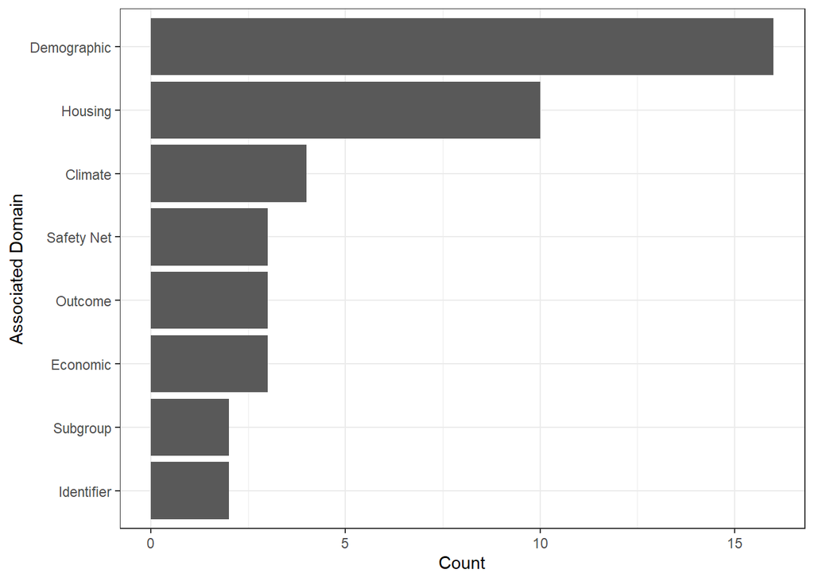

```r
dictionary_small %>%
  count(`Associated Domain`) %>%
  mutate(`Associated Domain` = fct_reorder(`Associated Domain`, n)) %>%
  ggplot(aes(x = `Associated Domain`, y = n)) +
  geom_col() +
  coord_flip() +
  labs(x = "Associated Domain", y = "Count")
```

Like the larger data set, most of the variables describe demographic and housing variables.

### Further exploration of basic properties

#### Check for a tidy data frame

In a tidy data set, each column is a variable or id and each row is an observation. It will take some work to determine whether the data set is tidy.

It was difficult to assess whether the full data frame was tidy because of the large number of columns with confusing names. We will do the analysis on the smaller data frame.

$\rightarrow$ How many observations are in the data set?

3008

### Data cleaning

#### Rename variables

I used the data dictionary to create more readable names for the minimal set of variables. You should add in new names for the additional variables you included in the data set.

The data frame with renamed columns is called `df_hud`.

```r
df_hud <- df_small %>%
  rename(coc_number = dictionary_small$Variable[2],
    total_sheltered = dictionary_small$Variable[3],
total_unsheltered = dictionary_small$Variable[4],
total_homeless = dictionary_small$Variable[5],
total_population = dictionary_small$Variable[6],
total_female_population = dictionary_small$Variable[7],
total_population_0_19 = dictionary_small$Variable[8],
total_population_65_plus = dictionary_small$Variable[9],
total_black = dictionary_small$Variable[10],
total_asian = dictionary_small$Variable[11],
total_pacific_islander = dictionary_small$Variable[12],
total_latino_hispanic = dictionary_small$Variable[13],
house_price_index_2009 = dictionary_small$Variable[14],
rate_unemployment = dictionary_small$Variable[15],
net_migration = dictionary_small$Variable[16],
HUD_unit_occupancy_rate = dictionary_small$Variable[17],
number_eviction = dictionary_small$Variable[18],
percentage_excessive_drinking = dictionary_small$Variable[19],
medicare_reimbursements_per_enrollee = dictionary_small$Variable[20],
average_summer_temperature = dictionary_small$Variable[21],
total_annual_precipitation = dictionary_small$Variable[22],
average_Jan_temperature = dictionary_small$Variable[23],
total_Jan_precipitation = dictionary_small$Variable[24],
gini_coefficient_2016 = dictionary_small$Variable[25],
poverty_rate = dictionary_small$Variable[26],
share_renters_2016 = dictionary_small$Variable[27],
share_overcrowded_units_2016 = dictionary_small$Variable[28],
percentage_owners_cost_burden_2016 = dictionary_small$Variable[29],
percentage_renters_severe_cost_burden_2016 = dictionary_small$Variable[30],
share_HUD_units = dictionary_small$Variable[31],
high_housing_density = dictionary_small$Variable[32],
share_built_before_1940  = dictionary_small$Variable[33],
utility_costs  = dictionary_small$Variable[34],
rental_vacancy_rate = dictionary_small$Variable[35],
proportion_one_person_households  = dictionary_small$Variable[36],
share_under_18_with_single_parent = dictionary_small$Variable[37],
share_veteran_status = dictionary_small$Variable[38],
log_median_rent = dictionary_small$Variable[39],
migration_4_year_change  = dictionary_small$Variable[40],
share_no_bachelors = dictionary_small$Variable[41],
city_or_urban = dictionary_small$Variable[42],
suburban = dictionary_small$Variable[43]
)
```

$\rightarrow$ Examine the head of the new data frame with the updated names:

```r
head(df_hud)
```

```
## # A tibble: 6 x 43
##    year coc_number total_homeless total_sheltered total_unsheltered
##   <dbl> <chr>               <dbl>           <dbl>             <dbl>
## 1  2010 AK-500               1231            1113               118
## 2  2011 AK-500               1223            1082               141
## 3  2012 AK-500               1147            1097                50
## 4  2013 AK-500               1122            1070                52
## 5  2014 AK-500               1023             970                53
## 6  2015 AK-500               1208            1029               179
## # ... with 38 more variables: total_population <dbl>,
## #   house_price_index_2009 <dbl>, log_median_rent <dbl>, utility_costs <dbl>,
## #   percentage_owners_cost_burden_2016 <dbl>,
## #   percentage_renters_severe_cost_burden_2016 <dbl>, share_renters_2016 <dbl>,
## #   rental_vacancy_rate <dbl>, high_housing_density <dbl>,
## #   number_eviction <dbl>, share_overcrowded_units_2016 <dbl>,
## #   city_or_urban <dbl>, suburban <dbl>, rate_unemployment <dbl>, ...
```

$\rightarrow$ Display the names of the columns of the new data frame:

```r
names(df_hud)
```

```
##  [1] "year"
##  [2] "coc_number"
##  [3] "total_homeless"
##  [4] "total_sheltered"
##  [5] "total_unsheltered"
##  [6] "total_population"
##  [7] "house_price_index_2009"
##  [8] "log_median_rent"
##  [9] "utility_costs"
## [10] "percentage_owners_cost_burden_2016"
## [11] "percentage_renters_severe_cost_burden_2016"
## [12] "share_renters_2016"
## [13] "rental_vacancy_rate"
## [14] "high_housing_density"
## [15] "number_eviction"
```

[output cut: 28 more lines]

### Identify and deal with missing values

$\rightarrow$ How many missing values are there in each column? Give the number of missing values and the percent of values in each column that are missing.

```r
skim(df_hud)
```

Data summary

| Name | df_hud |
| --- | --- |
| Number of rows | 3008 |
| Number of columns | 43 |
| _______________________ |  |
| Column type frequency: |  |
| character | 1 |
| numeric | 42 |
| ________________________ |  |
| Group variables | None |

**Variable type: character**

| skim_variable | n_missing | complete_rate | min | max | empty | n_unique | whitespace |
| --- | --- | --- | --- | --- | --- | --- | --- |
| coc_number | 0 | 1 | 6 | 7 | 0 | 376 | 0 |

**Variable type: numeric**

| skim_variable | n_missing | complete_rate | mean | sd | p0 | p25 | p50 | p75 | p100 | hist |
| --- | --- | --- | --- | --- | --- | --- | --- | --- | --- | --- |
| year | 0 | 1.00 | 2013.50 | 2.29 | 2010.00 | 2011.75 | 2013.50 | 2015.25 | 2017.00 | ▇▃▇▃▇ |
| total_homeless | 14 | 1.00 | 1560.43 | 4313.39 | 7.00 | 320.25 | 679.00 | 1468.00 | 76501.00 | ▇▁▁▁▁ |
| total_sheltered | 14 | 1.00 | 1033.85 | 3445.81 | 3.00 | 224.00 | 445.50 | 961.50 | 72565.00 | ▇▁▁▁▁ |
| total_unsheltered | 14 | 1.00 | 526.58 | 1742.31 | 0.00 | 36.25 | 114.00 | 418.25 | 42828.00 | ▇▁▁▁▁ |
| total_population | 0 | 1.00 | 837457.01 | 1217309.59 | 29344.00 | 266710.75 | 481798.50 | 896909.25 | 11058958.00 | ▇▁▁▁▁ |
| house_price_index_2009 | 0 | 1.00 | -2.74 | 10.14 | -26.50 | -8.61 | -3.28 | 0.00 | 63.86 | ▃▇▁▁▁ |
| log_median_rent | 1504 | 0.50 | 1.97 | 0.31 | 1.24 | 1.73 | 1.94 | 2.16 | 2.87 | ▂▇▇▃▁ |
| utility_costs | 1504 | 0.50 | 14.66 | 3.10 | 5.60 | 12.60 | 14.80 | 16.90 | 22.60 | ▁▅▇▇▁ |
| percentage_owners_cost_burden_2016 | 0 | 1.00 | 14.87 | 3.04 | 8.07 | 12.48 | 14.39 | 17.08 | 22.96 | ▂▇▆▅▁ |
| percentage_renters_severe_cost_burden_2016 | 0 | 1.00 | 25.54 | 3.86 | 16.38 | 22.86 | 25.00 | 27.76 | 37.65 | ▂▇▆▂▁ |
| share_renters_2016 | 0 | 1.00 | 34.55 | 8.23 | 15.10 | 28.64 | 33.52 | 39.66 | 69.22 | ▂▇▅▁▁ |
| rental_vacancy_rate | 1504 | 0.50 | 7.15 | 2.98 | 1.92 | 5.20 | 6.60 | 8.40 | 24.63 | ▇▇▁▁▁ |
| high_housing_density | 0 | 1.00 | 0.25 | 0.43 | 0.00 | 0.00 | 0.00 | 0.25 | 1.00 | ▇▁▁▁▂ |
| number_eviction | 0 | 1.00 | 2501.98 | 4314.93 | 0.00 | 96.75 | 935.50 | 2693.00 | 37105.00 | ▇▁▁▁▁ |
| share_overcrowded_units_2016 | 0 | 1.00 | 2.70 | 1.95 | 0.66 | 1.51 | 2.04 | 3.04 | 12.26 | ▇▂▁▁▁ |
| city_or_urban | 0 | 1.00 | 0.28 | 0.45 | 0.00 | 0.00 | 0.00 | 1.00 | 1.00 | ▇▁▁▁▃ |
| suburban | 0 | 1.00 | 0.43 | 0.49 | 0.00 | 0.00 | 0.00 | 1.00 | 1.00 | ▇▁▁▁▆ |
| rate_unemployment | 0 | 1.00 | 7.48 | 2.70 | 2.51 | 5.51 | 7.18 | 8.94 | 28.86 | ▇▅▁▁▁ |
| gini_coefficient_2016 | 0 | 1.00 | 45.52 | 2.85 | 37.56 | 43.70 | 45.40 | 46.99 | 54.78 | ▁▅▇▂▁ |
| poverty_rate | 0 | 1.00 | 14.42 | 4.46 | 3.35 | 11.45 | 14.32 | 17.31 | 35.79 | ▂▇▅▁▁ |
| share_HUD_units | 0 | 1.00 | 3.65 | 1.92 | 0.09 | 2.32 | 3.30 | 4.69 | 13.96 | ▆▇▂▁▁ |
| HUD_unit_occupancy_rate | 0 | 1.00 | 92.60 | 3.99 | 69.44 | 90.77 | 93.01 | 95.15 | 100.00 | ▁▁▂▇▇ |
| share_built_before_1940 | 1504 | 0.50 | 13.46 | 10.78 | 0.22 | 4.88 | 10.11 | 20.13 | 56.88 | ▇▃▂▁▁ |
| total_black | 0 | 1.00 | 103606.65 | 202325.49 | 152.00 | 10567.00 | 36742.00 | 109931.25 | 1956449.00 | ▇▁▁▁▁ |
| total_latino_hispanic | 0 | 1.00 | 142104.15 | 407635.29 | 224.00 | 14898.50 | 35744.50 | 92569.50 | 4924272.00 | ▇▁▁▁▁ |
| total_asian | 0 | 1.00 | 42375.38 | 117157.23 | 80.00 | 4291.75 | 11239.50 | 30542.50 | 1474987.00 | ▇▁▁▁▁ |
| total_pacific_islander | 0 | 1.00 | 1388.47 | 5558.70 | 1.00 | 117.00 | 259.00 | 642.25 | 89016.00 | ▇▁▁▁▁ |
| total_population_0_19 | 0 | 1.00 | 219436.13 | 329651.86 | 6194.00 | 67781.25 | 124462.00 | 234535.00 | 3204024.00 | ▇▁▁▁▁ |
| total_population_65_plus | 0 | 1.00 | 117131.31 | 161665.55 | 4781.00 | 38146.75 | 66976.00 | 124377.25 | 1525916.00 | ▇▁▁▁▁ |
| total_female_population | 0 | 1.00 | 425237.98 | 618118.92 | 14816.00 | 135979.25 | 244430.50 | 461586.00 | 5542088.00 | ▇▁▁▁▁ |
| net_migration | 0 | 1.00 | 2458.73 | 8426.78 | -41321.00 | -719.00 | 492.50 | 3207.75 | 101369.00 | ▁▇▁▁▁ |
| migration_4_year_change | 2632 | 0.12 | 0.07 | 0.68 | -3.45 | -0.26 | 0.02 | 0.36 | 2.60 | ▁▁▇▅▁ |
| proportion_one_person_households | 1504 | 0.50 | 27.73 | 4.15 | 12.48 | 25.40 | 27.82 | 30.10 | 46.71 | ▁▃▇▁▁ |
| share_under_18_with_single_parent | 1504 | 0.50 | 25.58 | 6.94 | 9.44 | 20.94 | 24.61 | 29.21 | 55.63 | ▂▇▃▁▁ |
| share_veteran_status | 1504 | 0.50 | 10.89 | 3.05 | 2.80 | 8.96 | 10.78 | 12.66 | 23.88 | ▂▇▆▁▁ |
| share_no_bachelors | 1504 | 0.50 | 69.69 | 10.30 | 23.69 | 64.34 | 71.09 | 77.36 | 88.64 | ▁▁▃▇▆ |
| medicare_reimbursements_per_enrollee | 0 | 1.00 | 9.36 | 1.25 | 6.03 | 8.44 | 9.22 | 10.08 | 17.95 | ▃▇▂▁▁ |
| percentage_excessive_drinking | 2632 | 0.12 | 0.19 | 0.03 | 0.11 | 0.17 | 0.19 | 0.21 | 0.29 | ▁▆▇▂▁ |
| average_Jan_temperature | 0 | 1.00 | 35.36 | 12.85 | -3.24 | 26.32 | 33.71 | 44.11 | 74.70 | ▁▅▇▃▁ |
| average_summer_temperature | 2 | 1.00 | 74.05 | 6.17 | 55.80 | 69.54 | 73.90 | 78.74 | 93.25 | ▁▆▇▅▁ |
| total_Jan_precipitation | 0 | 1.00 | 2.94 | 2.51 | 0.00 | 1.33 | 2.53 | 3.59 | 25.32 | ▇▁▁▁▁ |
| total_annual_precipitation | 0 | 1.00 | 41.03 | 15.36 | 1.25 | 33.52 | 42.03 | 49.96 | 105.19 | ▂▇▇▁▁ |

There are 14 missing values (0.4%) from total_homeless, total_sheltered, and total_unsheltered. There are 1504 missing values (50%) from log_median_rent, utility_costs, rental_vacancy_rate, share_built_before_1940, proportion_one_person_households, share_under_18_with_single_parent, share_veteran_status, and share_no_bachelors. There are 2632 missing values (87.5%) from migration_4_year_change and percentage_excessive_drinking. There are 2 missing values (0.06%) from average_summer_temperature.

We are interested in predicting the number of people experiencing homelessness. So, we will remove the rows where those numbers are missing.

$\rightarrow$ Remove the rows where `total_homeless` is `NA`.

```r
df_hud <- df_hud %>%
  filter(is.na(total_homeless) == FALSE)
```

There are some variables that are missing many of their values.

$\rightarrow$ Produce scatter plots of the variables that are missing many values vs. time to see if data are missing from particular years.

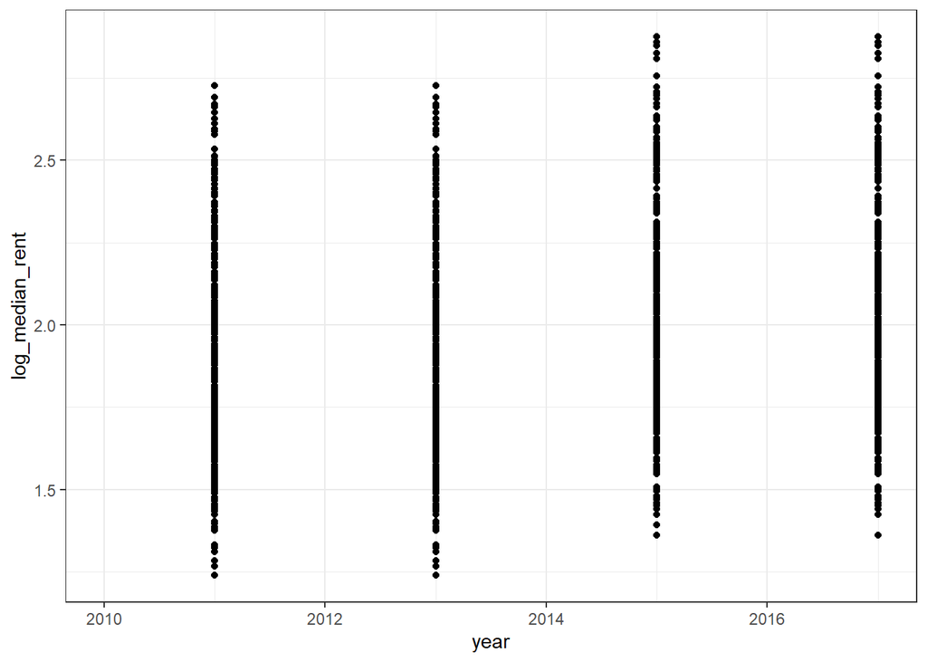

```r
# Plot three variables that have over 1000 missing values
ggplot(data = df_hud, aes(x = year, y = log_median_rent)) +
  geom_point()
```

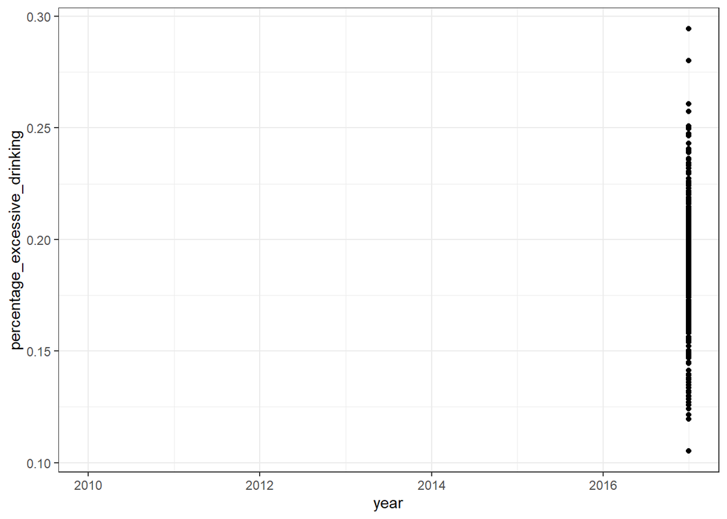

```r
ggplot(data = df_hud, aes(x = year, y = percentage_excessive_drinking)) +
  geom_point()
```

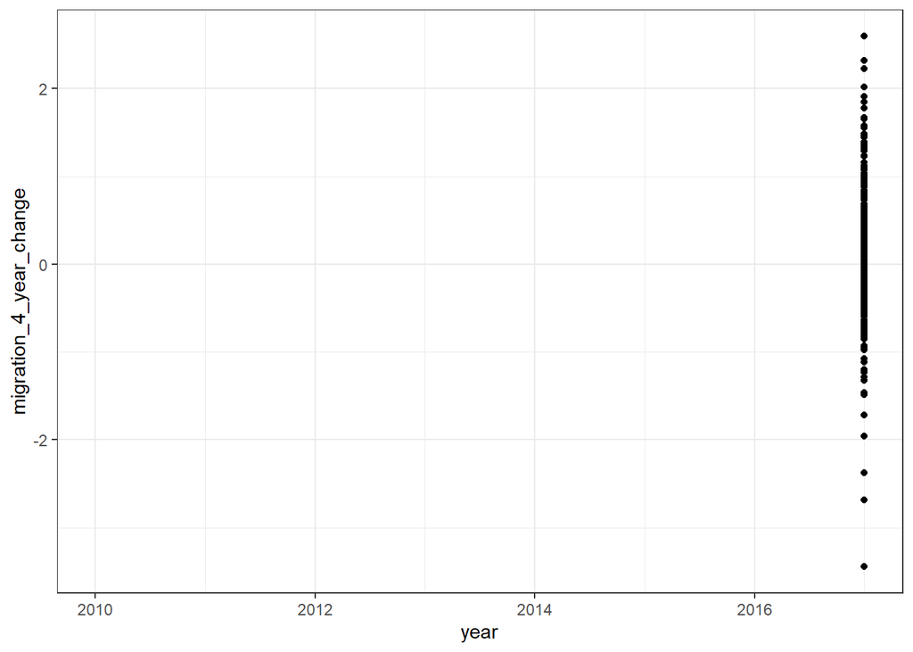

```r
ggplot(data = df_hud, aes(x = year, y = migration_4_year_change)) +
  geom_point()
```

Some variables only have data for 2017 (migration_4_year_change and percentage_excessive_drinking). These were the variables missing over 2000 values.

$\rightarrow$ Produce a data frame with data only from 2017. Call it `df_2017`.

```r
df_2017 <- df_hud %>%
  filter(year == 2017)
```

$\rightarrow$ Check for missing values in the 2017 data.

```r
skim(df_2017)
```

Data summary

| Name | df_2017 |
| --- | --- |
| Number of rows | 374 |
| Number of columns | 43 |
| _______________________ |  |
| Column type frequency: |  |
| character | 1 |
| numeric | 42 |
| ________________________ |  |
| Group variables | None |

**Variable type: character**

| skim_variable | n_missing | complete_rate | min | max | empty | n_unique | whitespace |
| --- | --- | --- | --- | --- | --- | --- | --- |
| coc_number | 0 | 1 | 6 | 7 | 0 | 374 | 0 |

**Variable type: numeric**

| skim_variable | n_missing | complete_rate | mean | sd | p0 | p25 | p50 | p75 | p100 | hist |
| --- | --- | --- | --- | --- | --- | --- | --- | --- | --- | --- |
| year | 0 | 1 | 2017.00 | 0.00 | 2017.00 | 2017.00 | 2017.00 | 2017.00 | 2017.00 | ▁▁▇▁▁ |
| total_homeless | 0 | 1 | 1466.07 | 5114.12 | 10.00 | 282.75 | 567.50 | 1203.00 | 76501.00 | ▇▁▁▁▁ |
| total_sheltered | 0 | 1 | 961.68 | 3921.31 | 5.00 | 189.00 | 373.00 | 850.75 | 72565.00 | ▇▁▁▁▁ |
| total_unsheltered | 0 | 1 | 504.39 | 2334.30 | 0.00 | 37.00 | 109.50 | 384.00 | 42828.00 | ▇▁▁▁▁ |
| total_population | 0 | 1 | 862794.07 | 1257003.13 | 29344.00 | 271652.75 | 498140.50 | 924319.75 | 11058958.00 | ▇▁▁▁▁ |
| house_price_index_2009 | 0 | 1 | 6.90 | 14.68 | -17.53 | -2.61 | 3.12 | 13.51 | 63.86 | ▆▇▂▁▁ |
| log_median_rent | 0 | 1 | 2.02 | 0.31 | 1.36 | 1.80 | 1.98 | 2.20 | 2.87 | ▂▇▆▃▁ |
| utility_costs | 0 | 1 | 14.84 | 2.97 | 5.90 | 12.95 | 14.97 | 17.16 | 22.60 | ▁▃▇▆▁ |
| percentage_owners_cost_burden_2016 | 0 | 1 | 14.88 | 3.04 | 8.07 | 12.49 | 14.40 | 17.09 | 22.96 | ▂▇▆▅▁ |
| percentage_renters_severe_cost_burden_2016 | 0 | 1 | 25.55 | 3.87 | 16.38 | 22.89 | 25.00 | 27.82 | 37.65 | ▂▇▆▃▁ |
| share_renters_2016 | 0 | 1 | 34.57 | 8.26 | 15.10 | 28.58 | 33.53 | 39.71 | 69.22 | ▂▇▅▁▁ |
| rental_vacancy_rate | 0 | 1 | 6.47 | 2.73 | 1.92 | 4.78 | 6.24 | 7.61 | 21.05 | ▆▇▁▁▁ |
| high_housing_density | 0 | 1 | 0.25 | 0.44 | 0.00 | 0.00 | 0.00 | 1.00 | 1.00 | ▇▁▁▁▃ |
| number_eviction | 0 | 1 | 2402.04 | 4297.43 | 0.00 | 75.75 | 854.50 | 2441.00 | 36357.00 | ▇▁▁▁▁ |
| share_overcrowded_units_2016 | 0 | 1 | 2.71 | 1.96 | 0.66 | 1.51 | 2.04 | 3.05 | 12.26 | ▇▂▁▁▁ |
| city_or_urban | 0 | 1 | 0.28 | 0.45 | 0.00 | 0.00 | 0.00 | 1.00 | 1.00 | ▇▁▁▁▃ |
| suburban | 0 | 1 | 0.43 | 0.50 | 0.00 | 0.00 | 0.00 | 1.00 | 1.00 | ▇▁▁▁▆ |
| rate_unemployment | 0 | 1 | 5.00 | 1.57 | 2.51 | 4.14 | 4.90 | 5.57 | 23.64 | ▇▁▁▁▁ |
| gini_coefficient_2016 | 0 | 1 | 45.53 | 2.86 | 37.56 | 43.71 | 45.40 | 47.00 | 54.78 | ▁▅▇▂▁ |
| poverty_rate | 0 | 1 | 13.41 | 4.14 | 3.50 | 10.50 | 13.23 | 16.08 | 25.56 | ▂▆▇▃▁ |
| share_HUD_units | 0 | 1 | 3.53 | 1.84 | 0.09 | 2.24 | 3.22 | 4.57 | 11.86 | ▅▇▃▁▁ |
| HUD_unit_occupancy_rate | 0 | 1 | 92.42 | 4.08 | 73.00 | 90.13 | 93.00 | 95.00 | 100.00 | ▁▁▂▇▅ |
| share_built_before_1940 | 0 | 1 | 13.04 | 10.52 | 0.26 | 4.58 | 9.91 | 19.21 | 56.01 | ▇▃▂▁▁ |
| total_black | 0 | 1 | 107580.71 | 207495.53 | 244.00 | 11811.25 | 37467.50 | 113661.50 | 1909362.00 | ▇▁▁▁▁ |
| total_latino_hispanic | 0 | 1 | 154259.52 | 431612.58 | 344.00 | 17374.50 | 39273.00 | 100622.25 | 4924272.00 | ▇▁▁▁▁ |
| total_asian | 0 | 1 | 47716.18 | 128225.20 | 106.00 | 5367.00 | 12655.50 | 34762.75 | 1474987.00 | ▇▁▁▁▁ |
| total_pacific_islander | 0 | 1 | 1512.28 | 5793.14 | 1.00 | 130.00 | 290.50 | 697.25 | 88323.00 | ▇▁▁▁▁ |
| total_population_0_19 | 0 | 1 | 219133.87 | 329833.51 | 6194.00 | 67203.00 | 125673.00 | 236132.50 | 3204024.00 | ▇▁▁▁▁ |
| total_population_65_plus | 0 | 1 | 131381.43 | 180215.56 | 6218.00 | 42612.75 | 75493.50 | 138750.00 | 1525916.00 | ▇▁▁▁▁ |
| total_female_population | 0 | 1 | 437977.63 | 638095.05 | 14823.00 | 137737.75 | 252411.00 | 473421.25 | 5542088.00 | ▇▁▁▁▁ |
| net_migration | 0 | 1 | 3030.79 | 10140.42 | -41321.00 | -990.25 | 442.00 | 3645.50 | 91270.00 | ▁▇▁▁▁ |
| migration_4_year_change | 0 | 1 | 0.07 | 0.68 | -3.45 | -0.26 | 0.02 | 0.36 | 2.60 | ▁▁▇▅▁ |
| proportion_one_person_households | 0 | 1 | 28.00 | 4.17 | 12.48 | 25.54 | 28.18 | 30.34 | 44.69 | ▁▃▇▂▁ |
| share_under_18_with_single_parent | 0 | 1 | 25.76 | 6.89 | 9.77 | 21.02 | 24.81 | 29.44 | 54.47 | ▂▇▅▁▁ |
| share_veteran_status | 0 | 1 | 9.94 | 2.86 | 2.80 | 8.16 | 10.07 | 11.28 | 22.27 | ▂▇▅▁▁ |
| share_no_bachelors | 0 | 1 | 68.89 | 10.45 | 23.69 | 63.02 | 70.41 | 76.62 | 88.37 | ▁▁▃▇▅ |
| medicare_reimbursements_per_enrollee | 0 | 1 | 9.91 | 1.21 | 6.79 | 9.02 | 9.70 | 10.61 | 14.31 | ▁▇▆▂▁ |
| percentage_excessive_drinking | 0 | 1 | 0.19 | 0.03 | 0.11 | 0.17 | 0.19 | 0.21 | 0.29 | ▁▆▇▂▁ |
| average_Jan_temperature | 0 | 1 | 39.10 | 12.07 | 10.98 | 30.30 | 37.48 | 46.48 | 73.50 | ▁▇▇▃▁ |
| average_summer_temperature | 0 | 1 | 75.16 | 5.87 | 59.55 | 71.27 | 75.23 | 79.67 | 93.25 | ▂▆▇▅▁ |
| total_Jan_precipitation | 0 | 1 | 4.39 | 3.68 | 0.21 | 2.47 | 3.39 | 4.70 | 25.32 | ▇▂▁▁▁ |
| total_annual_precipitation | 0 | 1 | 39.43 | 13.69 | 3.06 | 33.84 | 38.58 | 45.04 | 96.34 | ▂▇▅▁▁ |

There are no missing values in the 2017 data set.

## Exploratory data analysis

We have two main goals when doing exploratory data analysis. The first is that we want to understand the data set more completely. The second goal is to explore relationships between the variables to help guide the modeling process to answer our specific question.

### Graphical summaries

#### Look at the distributions of the homeless counts

$\rightarrow$ Make a histogram of the total number of homeless in 2017.

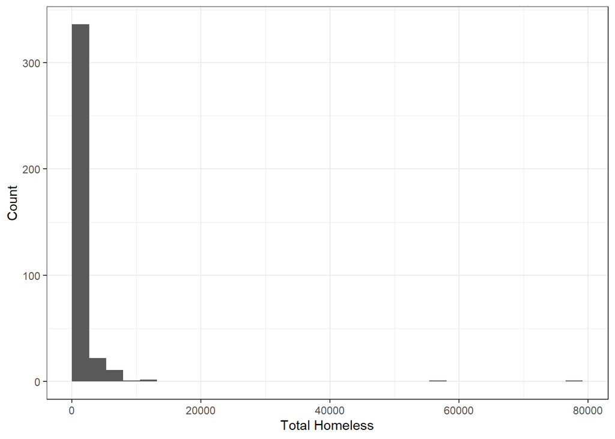

```r
ggplot(data = df_2017, aes(x = total_homeless)) +
  geom_histogram(boundary = 0) +
  labs(x = "Total Homeless", y = "Count")
```

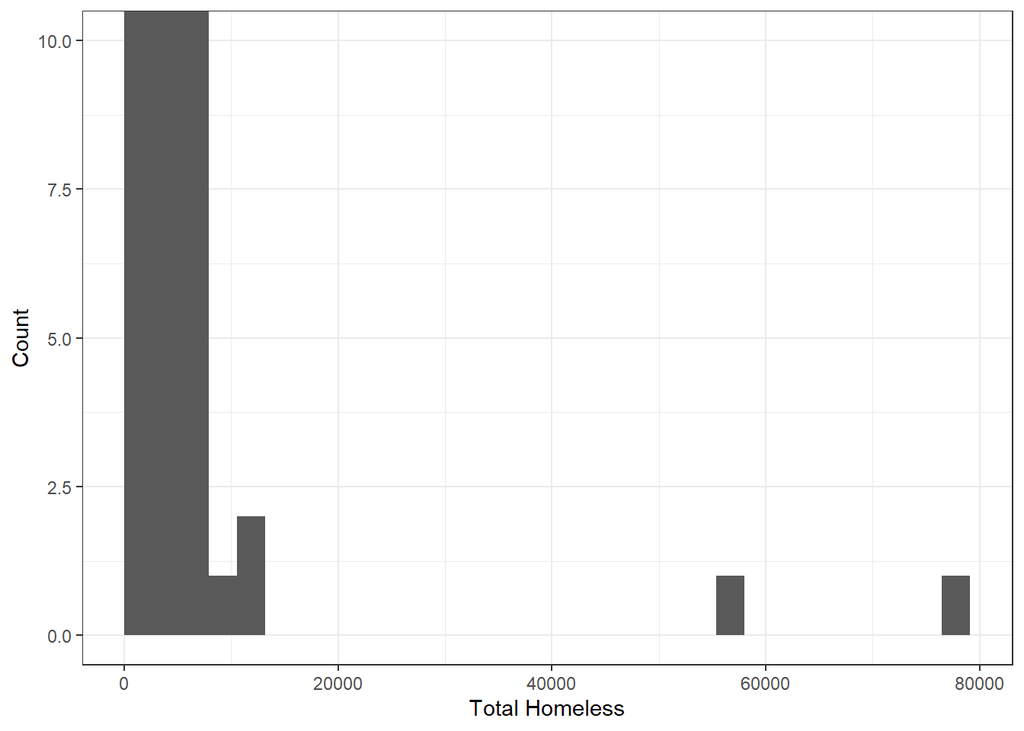

```r
# Set limits to better see the outlier values
ggplot(data = df_2017, aes(x = total_homeless)) +
  geom_histogram(boundary = 0) +
  coord_cartesian(ylim = c(0, 10)) +
  labs(x = "Total Homeless", y = "Count")
```

The data is mostly positively skewed, with lots of data points close to 0. There are also some outliers that are higher numbers, probably for larger cities.

#### Look at population distribution

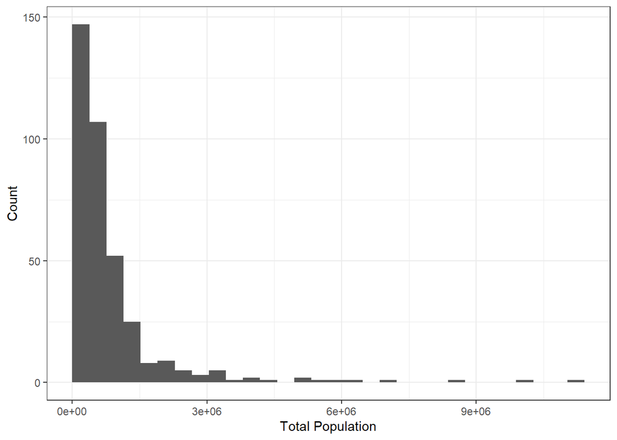

```r
ggplot(data = df_2017, aes(x = total_population)) +
  geom_histogram(boundary = 0) +
  labs(x = "Total Population", y = "Count")
```

The total population histogram is also positively skewed. Most of the data points are near 0, with some outliers with higher populations. It matches the same shape as the total_homeless histogram.

$\rightarrow$ Make a histogram of the number of sheltered homeless in 2017.

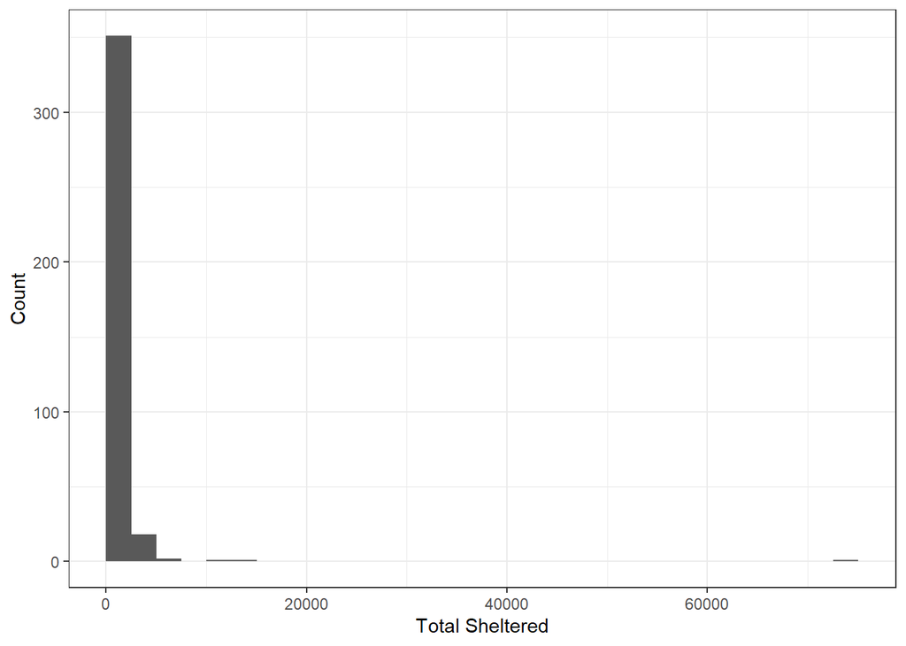

```r
ggplot(data = df_2017, aes(x = total_sheltered)) +
  geom_histogram(boundary = 0) +
  labs(x = "Total Sheltered", y = "Count")
```

$\rightarrow$ Make a histogram of the number of unsheltered homeless in 2017.

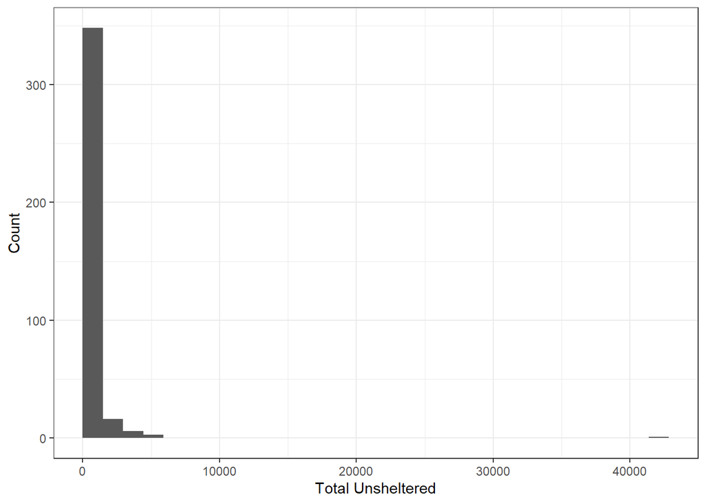

```r
ggplot(data = df_2017, aes(x = total_unsheltered)) +
  geom_histogram(boundary = 0) +
  labs(x = "Total Unsheltered", y = "Count")
```

The graph is also positively skewed, with an outlier past 40000. It matches all the other population graphs so far.

Converting the total counts to rates relative to population size should remove extreme outliers.

$\rightarrow$ Use the `mutate` function to create a new variable `rate_homeless` that is the total number of homeless per 10,000 people in the population and make a histogram of `rate_homeless`.

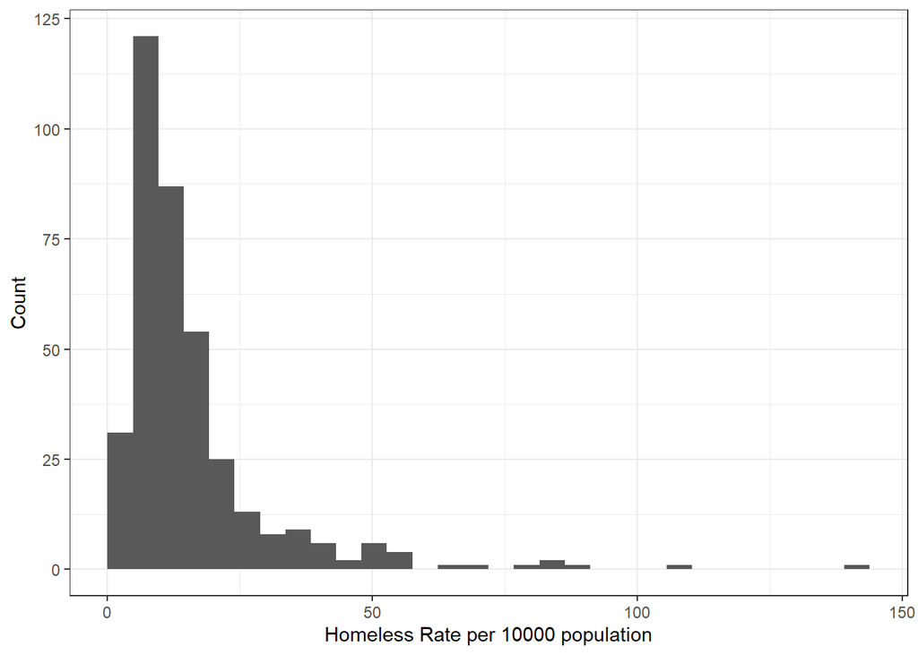

```r
df_2017 <- df_2017 %>%
  mutate(rate_homeless = total_homeless / (total_population / 10000))
ggplot(data = df_2017, aes(x = rate_homeless)) +
  geom_histogram(boundary = 0) +
  labs(x = "Homeless Rate per 10000 population", y = "Count")
```

The distribution is unimodal and positively skewed, though less skewed than the previous total homeless histogram. Most of the points continue to be clustered around the far left side of the graph. There are still outlier points on the right side of the graph.

$\rightarrow$ Compare boxplots of `rate_homeless` and `total_homeless` to visually assess whether outliers are less extreme in `rate_homeless` than in `total_homeless`.

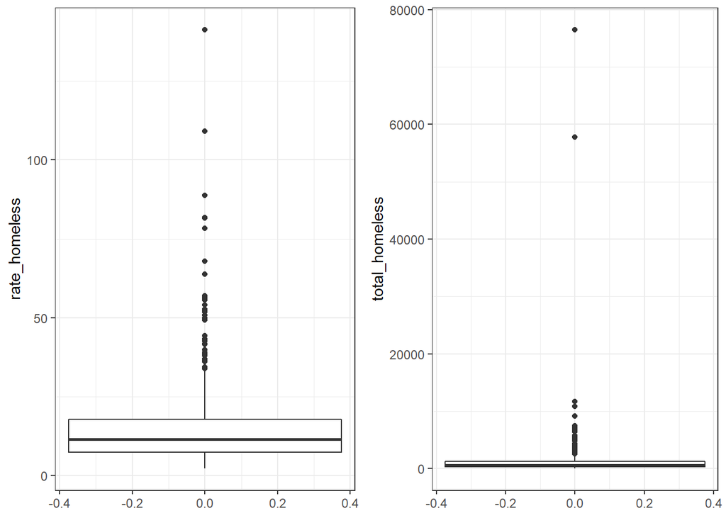

```r
r <- ggplot(data = df_2017) +
  geom_boxplot(aes(y = rate_homeless))
t <- ggplot(data = df_2017) +
  geom_boxplot(aes(y = total_homeless))
grid.arrange(r, t, nrow = 1)
```

The outliers in the total_homeless box plot are more extreme. The quartiles of that box plot are harder to see, and it has two outlier points that are much higher than anything else on the plot. While the rate_homeless box plot also as a few outliers, they and the box can all be easily distinguished.

#### Data processing

We will add rates to the data frame. Following the HUD report, we will produce rates per 10,000 people.

$\rightarrow$ Use the `mutate` function to create new variables `rate_homeless`, `rate_sheltered`, and `rate_unsheltered` in the data frame `df_2017` that are the counts per 10,000 people in the population.

```r
df_2017 <- df_2017 %>%
  mutate(
    rate_sheltered = total_sheltered / (total_population / 10000),
    rate_unsheltered = total_unsheltered / (total_population / 10000))
```

We should note that the demographic variables (race, gender, age) are given as total counts. We will also convert these totals to percentages.

$\rightarrow$ Use the `mutate` function to create new demographics variables in the data frame `df_2017` that are percentages of the total population.

```r
# Convert all totals to percentages
df_2017 <- df_2017 %>%
  mutate(
    percent_black = total_black / total_population,
    percent_asian = total_asian / total_population,
    percent_latino_hispanic = total_latino_hispanic / total_population,
    percent_pacific_islander = total_pacific_islander / total_population,
    percent_0_19 = total_population_0_19 / total_population,
    percent_65_plus = total_population_65_plus / total_population,
    percent_female = total_female_population / total_population
  )
```

#### Basic summary

$\rightarrow$ How many people were experiencing homelessness in 2017? How many were sheltered and how many were unsheltered?

```r
df_2017 %>%
  select(total_homeless, total_sheltered, total_unsheltered) %>%
  colSums()
```

```
##    total_homeless   total_sheltered total_unsheltered
##            548312            359669            188643
```

548312 people were homeless in 2017. 359669 of them were sheltered, and 188643 people were unsheltered.

$\rightarrow$ What are the minimum, maximum, mean, and median number of total, sheltered, and unsheltered homeless in 2017?

```r
df_2017 %>%
  select(total_homeless, total_sheltered, total_unsheltered) %>%
  summary()
```

```
##  total_homeless    total_sheltered   total_unsheltered
##  Min.   :   10.0   Min.   :    5.0   Min.   :    0.0
##  1st Qu.:  282.8   1st Qu.:  189.0   1st Qu.:   37.0
##  Median :  567.5   Median :  373.0   Median :  109.5
##  Mean   : 1466.1   Mean   :  961.7   Mean   :  504.4
##  3rd Qu.: 1203.0   3rd Qu.:  850.8   3rd Qu.:  384.0
##  Max.   :76501.0   Max.   :72565.0   Max.   :42828.0
```

Total homeless minimum: 10 Total homeless maximum: 76501 Total homeless mean: 1466.1 Total homeless median: 567.5

Total sheltered minimum: 5 Total sheltered maximum: 72565 Total sheltered mean: 961.7 Total sheltered median: 373

Total unsheltered minimum: 0 Total unsheltered maximum: 42828 Total unsheltered mean: 504.4 Total unsheltered median: 109.5

### Correlations between numerical variables

$\rightarrow$ Plot the correlation coefficients between all pairs of numerical variables using the `corrplot` function.

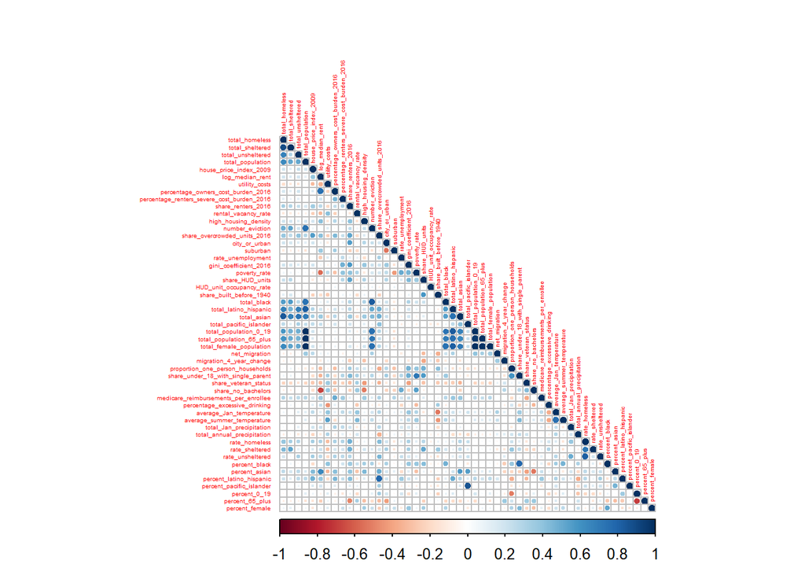

```r
df_2017 %>%
  select_if(is.numeric) %>%
  select(-"year") %>%
  cor(use = "pairwise.complete.obs") %>%
  corrplot(tl.cex = 0.3, type = "lower")
```

There are some variables that are highly correlated with the rate of homeless. Some are obvious, such as the rate of sheltered homeless. Other correlations show the existence of environmental variables, such as the share of overcrowded units, that are correlated with the rate of homeless.

Note the high correlation among subsets of the input variables. We will want to remove redundant variables or make a transformation of the input variables to deal with the correlation before constructing a model.

Next, we will find the variables with the highest correlation with `rate_homeless`. First, create the correlation matrix. Then examine the row with `rate_homeless` to find its correlation with the other variables.

```r
M <- df_2017 %>%
  select_if(is.numeric) %>%
  cor(use = "pairwise.complete.obs")
round(M["rate_homeless",],2)
```

```
##                                       year
##                                         NA
##                             total_homeless
##                                       0.39
##                            total_sheltered
##                                       0.33
##                          total_unsheltered
##                                       0.29
##                           total_population
##                                       0.05
##                     house_price_index_2009
##                                       0.34
##                            log_median_rent
##                                       0.31
##                              utility_costs
##                                      -0.31
##         percentage_owners_cost_burden_2016
##                                       0.32
## percentage_renters_severe_cost_burden_2016
##                                       0.30
##                         share_renters_2016
##                                       0.48
##                        rental_vacancy_rate
##                                      -0.08
##                       high_housing_density
##                                       0.08
##                            number_eviction
##                                       0.03
##               share_overcrowded_units_2016
##                                       0.42
##                              city_or_urban
##                                       0.19
##                                   suburban
##                                      -0.12
##                          rate_unemployment
##                                       0.13
##                      gini_coefficient_2016
##                                       0.31
##                               poverty_rate
##                                       0.13
```

[output cut: 49 more lines]

```
##                                       0.83
##                              percent_black
##                                      -0.04
##                              percent_asian
##                                       0.25
##                    percent_latino_hispanic
##                                       0.28
##                   percent_pacific_islander
##                                       0.22
##                               percent_0_19
##                                      -0.20
##                            percent_65_plus
##                                       0.00
##                             percent_female
##                                      -0.08
```

Find the variables where the absolute value of the correlation with `rate_homeless` is greater than 0.3.

```r
M["rate_homeless",abs(M["rate_homeless",]) > 0.3 & is.na(M["rate_homeless",]) == FALSE] %>%
  abs() %>%
  round(2) %>%
  sort(decreasing = T)
```

```
##                      rate_homeless                   rate_unsheltered
##                               1.00                               0.83
##                     rate_sheltered                 share_renters_2016
##                               0.72                               0.48
##       share_overcrowded_units_2016                     total_homeless
##                               0.42                               0.39
##            total_Jan_precipitation             house_price_index_2009
##                               0.37                               0.34
##                    total_sheltered percentage_owners_cost_burden_2016
##                               0.33                               0.32
##                    log_median_rent                      utility_costs
##                               0.31                               0.31
##              gini_coefficient_2016
##                               0.31
```

There are 13 variables with correlation coefficients greater than 0.3.

$\rightarrow$ Make a pairs plot with a subset of the variables with the highest magnitude correlations. Select a small enough group so that you can see the panels. Do not include variables that you will not use as predictors (e.g. `rate_unsheltered`, any demographic totals)

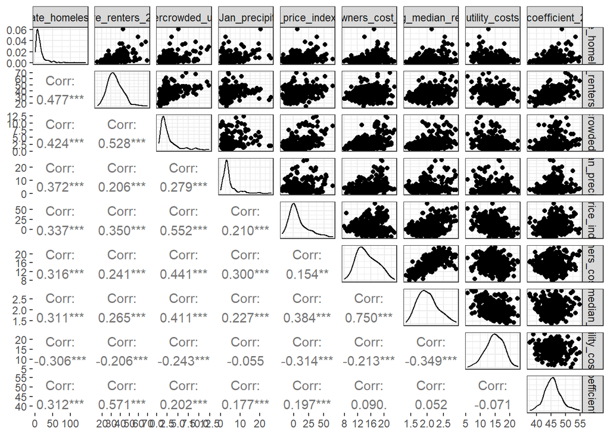

```r
df_2017 %>%
  select("rate_homeless", "share_renters_2016", "share_overcrowded_units_2016", "total_Jan_precipitation", "house_price_index_2009", "percentage_owners_cost_burden_2016", "log_median_rent", "utility_costs", "gini_coefficient_2016") %>%
  filter("coc_number" != "CA-613") %>%
  ggpairs(progress = FALSE, lower = list(continuous = "cor"), upper = list(continuous = "points"))
```

$\rightarrow$ Create additional plots to further understand the data set. Describe your findings.

[figure not shown]

```r
# Plot rate_homeless vs share_renters_2016
ggplot(data = df_2017, mapping = aes(x = share_renters_2016, y = rate_homeless)) +
  geom_point() +
  labs(x = "Share Renters 2016", y = "Homeless Rate per 10000 people")
```

Share_renters_2016 was the predictor with the highest correlation (0.48). The relationship between homeless rate and share_renters_2016 does not appear to be linear, since there are many points clustered near the bottom, and few higher up. An exponential relationship might fit the data better.

[figure not shown]

```r
ggplot(data = df_2017, mapping = aes(x = share_overcrowded_units_2016, y = rate_homeless)) +
  geom_point() +
  labs(x = "Share Overcrowded Units 2016", y = "Homeless Rate per 10000 people")
```

Share_overcrowded_units_2016 had the second highest coefficient (0.42). This relationship also does not appear linear. Many points are clustered on the bottom left of the graph.

[figure not shown]

```r
ggplot(data = df_2017, mapping = aes(x = total_Jan_precipitation, y = rate_homeless)) +
  geom_point() +
  labs(x = "Total January Precipitation", y = "Homeless Rate per 10000 people")
```

Total_Jan_precipitation had the third highest correlation (0.37). It also does not appear to have a linear relationship. It also has a larger spread of points, where there are many points with high precipitation.

## Model

We will multiple approaches to construct models that predict `rate_homeless`:

1. Use statistical significance to create a multiple linear regression model.
2. Best subset selection for a multiple linear regression model.
3. Lasso
4. Ridge regression
5. XGBoost

To compare the different approaches, we will use a training and testing split of the data set.

### Set up the data set for training and testing

#### Remove some variables

There are several variables that we do not want to include as predictors. We want to remove demographic totals, the year, the CoC number, and the other homeless rates that we are not predicting. You may have additional variables to remove to create the data set that contains only the response variable and the predictors that you want to use.

```r
# Remove non predictor variables
variable_remove = c("total_homeless", "total_sheltered", "total_unsheltered", "total_black", "total_latino_hispanic", "total_asian", "total_pacific_islander", "total_population_0_19", "total_population_65_plus", "total_female_population", "year", "coc_number", "total_population", "rate_unsheltered", "rate_sheltered")

df_2017 <- df_2017 %>%
  select(-all_of(variable_remove))

# Display remaining variables
names(df_2017)
```

```
##  [1] "house_price_index_2009"
##  [2] "log_median_rent"
##  [3] "utility_costs"
##  [4] "percentage_owners_cost_burden_2016"
##  [5] "percentage_renters_severe_cost_burden_2016"
##  [6] "share_renters_2016"
##  [7] "rental_vacancy_rate"
##  [8] "high_housing_density"
##  [9] "number_eviction"
## [10] "share_overcrowded_units_2016"
## [11] "city_or_urban"
## [12] "suburban"
## [13] "rate_unemployment"
## [14] "gini_coefficient_2016"
## [15] "poverty_rate"
```

[output cut: 23 more lines]

These variables are removed because they do not work as predictor variables for the homelessness rate. Instead, many of them are directly related, such as the total_homeless, rate_unsheltered, and rate_sheltered. Because of the different population sizes in various cities, we want to use rates instead of total numbers, which is why all of those variables are removed from the data set.

$\rightarrow$ How many input variables remain in the data set that you can use as predictors?

```r
skim(df_2017)
```

Data summary

| Name | df_2017 |
| --- | --- |
| Number of rows | 374 |
| Number of columns | 38 |
| _______________________ |  |
| Column type frequency: |  |
| numeric | 38 |
| ________________________ |  |
| Group variables | None |

**Variable type: numeric**

| skim_variable | n_missing | complete_rate | mean | sd | p0 | p25 | p50 | p75 | p100 | hist |
| --- | --- | --- | --- | --- | --- | --- | --- | --- | --- | --- |
| house_price_index_2009 | 0 | 1 | 6.90 | 14.68 | -17.53 | -2.61 | 3.12 | 13.51 | 63.86 | ▆▇▂▁▁ |
| log_median_rent | 0 | 1 | 2.02 | 0.31 | 1.36 | 1.80 | 1.98 | 2.20 | 2.87 | ▂▇▆▃▁ |
| utility_costs | 0 | 1 | 14.84 | 2.97 | 5.90 | 12.95 | 14.97 | 17.16 | 22.60 | ▁▃▇▆▁ |
| percentage_owners_cost_burden_2016 | 0 | 1 | 14.88 | 3.04 | 8.07 | 12.49 | 14.40 | 17.09 | 22.96 | ▂▇▆▅▁ |
| percentage_renters_severe_cost_burden_2016 | 0 | 1 | 25.55 | 3.87 | 16.38 | 22.89 | 25.00 | 27.82 | 37.65 | ▂▇▆▃▁ |
| share_renters_2016 | 0 | 1 | 34.57 | 8.26 | 15.10 | 28.58 | 33.53 | 39.71 | 69.22 | ▂▇▅▁▁ |
| rental_vacancy_rate | 0 | 1 | 6.47 | 2.73 | 1.92 | 4.78 | 6.24 | 7.61 | 21.05 | ▆▇▁▁▁ |
| high_housing_density | 0 | 1 | 0.25 | 0.44 | 0.00 | 0.00 | 0.00 | 1.00 | 1.00 | ▇▁▁▁▃ |
| number_eviction | 0 | 1 | 2402.04 | 4297.43 | 0.00 | 75.75 | 854.50 | 2441.00 | 36357.00 | ▇▁▁▁▁ |
| share_overcrowded_units_2016 | 0 | 1 | 2.71 | 1.96 | 0.66 | 1.51 | 2.04 | 3.05 | 12.26 | ▇▂▁▁▁ |
| city_or_urban | 0 | 1 | 0.28 | 0.45 | 0.00 | 0.00 | 0.00 | 1.00 | 1.00 | ▇▁▁▁▃ |
| suburban | 0 | 1 | 0.43 | 0.50 | 0.00 | 0.00 | 0.00 | 1.00 | 1.00 | ▇▁▁▁▆ |
| rate_unemployment | 0 | 1 | 5.00 | 1.57 | 2.51 | 4.14 | 4.90 | 5.57 | 23.64 | ▇▁▁▁▁ |
| gini_coefficient_2016 | 0 | 1 | 45.53 | 2.86 | 37.56 | 43.71 | 45.40 | 47.00 | 54.78 | ▁▅▇▂▁ |
| poverty_rate | 0 | 1 | 13.41 | 4.14 | 3.50 | 10.50 | 13.23 | 16.08 | 25.56 | ▂▆▇▃▁ |
| share_HUD_units | 0 | 1 | 3.53 | 1.84 | 0.09 | 2.24 | 3.22 | 4.57 | 11.86 | ▅▇▃▁▁ |
| HUD_unit_occupancy_rate | 0 | 1 | 92.42 | 4.08 | 73.00 | 90.13 | 93.00 | 95.00 | 100.00 | ▁▁▂▇▅ |
| share_built_before_1940 | 0 | 1 | 13.04 | 10.52 | 0.26 | 4.58 | 9.91 | 19.21 | 56.01 | ▇▃▂▁▁ |
| net_migration | 0 | 1 | 3030.79 | 10140.42 | -41321.00 | -990.25 | 442.00 | 3645.50 | 91270.00 | ▁▇▁▁▁ |
| migration_4_year_change | 0 | 1 | 0.07 | 0.68 | -3.45 | -0.26 | 0.02 | 0.36 | 2.60 | ▁▁▇▅▁ |
| proportion_one_person_households | 0 | 1 | 28.00 | 4.17 | 12.48 | 25.54 | 28.18 | 30.34 | 44.69 | ▁▃▇▂▁ |
| share_under_18_with_single_parent | 0 | 1 | 25.76 | 6.89 | 9.77 | 21.02 | 24.81 | 29.44 | 54.47 | ▂▇▅▁▁ |
| share_veteran_status | 0 | 1 | 9.94 | 2.86 | 2.80 | 8.16 | 10.07 | 11.28 | 22.27 | ▂▇▅▁▁ |
| share_no_bachelors | 0 | 1 | 68.89 | 10.45 | 23.69 | 63.02 | 70.41 | 76.62 | 88.37 | ▁▁▃▇▅ |
| medicare_reimbursements_per_enrollee | 0 | 1 | 9.91 | 1.21 | 6.79 | 9.02 | 9.70 | 10.61 | 14.31 | ▁▇▆▂▁ |
| percentage_excessive_drinking | 0 | 1 | 0.19 | 0.03 | 0.11 | 0.17 | 0.19 | 0.21 | 0.29 | ▁▆▇▂▁ |
| average_Jan_temperature | 0 | 1 | 39.10 | 12.07 | 10.98 | 30.30 | 37.48 | 46.48 | 73.50 | ▁▇▇▃▁ |
| average_summer_temperature | 0 | 1 | 75.16 | 5.87 | 59.55 | 71.27 | 75.23 | 79.67 | 93.25 | ▂▆▇▅▁ |
| total_Jan_precipitation | 0 | 1 | 4.39 | 3.68 | 0.21 | 2.47 | 3.39 | 4.70 | 25.32 | ▇▂▁▁▁ |
| total_annual_precipitation | 0 | 1 | 39.43 | 13.69 | 3.06 | 33.84 | 38.58 | 45.04 | 96.34 | ▂▇▅▁▁ |
| rate_homeless | 0 | 1 | 15.90 | 15.52 | 2.22 | 7.36 | 11.51 | 17.75 | 141.31 | ▇▁▁▁▁ |
| percent_black | 0 | 1 | 0.12 | 0.12 | 0.00 | 0.03 | 0.08 | 0.16 | 0.62 | ▇▂▁▁▁ |
| percent_asian | 0 | 1 | 0.04 | 0.05 | 0.00 | 0.01 | 0.03 | 0.05 | 0.42 | ▇▁▁▁▁ |
| percent_latino_hispanic | 0 | 1 | 0.13 | 0.13 | 0.01 | 0.05 | 0.08 | 0.16 | 0.84 | ▇▂▁▁▁ |
| percent_pacific_islander | 0 | 1 | 0.00 | 0.01 | 0.00 | 0.00 | 0.00 | 0.00 | 0.11 | ▇▁▁▁▁ |
| percent_0_19 | 0 | 1 | 0.25 | 0.03 | 0.14 | 0.23 | 0.25 | 0.26 | 0.37 | ▁▃▇▁▁ |
| percent_65_plus | 0 | 1 | 0.16 | 0.04 | 0.08 | 0.14 | 0.16 | 0.18 | 0.39 | ▃▇▁▁▁ |
| percent_female | 0 | 1 | 0.51 | 0.01 | 0.46 | 0.50 | 0.51 | 0.51 | 0.53 | ▁▁▃▇▂ |

There are 37 variables that can be used as predictors, and 374 observations. This can make it difficult to pick the best model, since it would be easier to overfit the data. The model could be accurate to the small data set, but not be able to predict any new data.

#### Get train and test splits

We will split the data into training and testing sets, with 85% of the data kept for training.

```r
# Set seed
set.seed(20)

# Split data (85% training, 15% test)
split <- initial_split(df_2017, prop = 0.85, strata = rate_homeless)

# Get train/test split
df_train <- training(split)
df_test <- testing(split)
```

$\rightarrow$ Check the sizes of the training and testing splits

```r
skim_without_charts(df_train)
```

Data summary

| Name | df_train |
| --- | --- |
| Number of rows | 316 |
| Number of columns | 38 |
| _______________________ |  |
| Column type frequency: |  |
| numeric | 38 |
| ________________________ |  |
| Group variables | None |

**Variable type: numeric**

| skim_variable | n_missing | complete_rate | mean | sd | p0 | p25 | p50 | p75 | p100 |
| --- | --- | --- | --- | --- | --- | --- | --- | --- | --- |
| house_price_index_2009 | 0 | 1 | 7.28 | 14.98 | -17.53 | -2.43 | 3.54 | 14.10 | 63.86 |
| log_median_rent | 0 | 1 | 2.03 | 0.32 | 1.36 | 1.80 | 2.00 | 2.22 | 2.87 |
| utility_costs | 0 | 1 | 14.79 | 2.98 | 5.90 | 12.90 | 14.86 | 17.12 | 22.49 |
| percentage_owners_cost_burden_2016 | 0 | 1 | 14.89 | 3.10 | 8.07 | 12.48 | 14.40 | 17.11 | 22.96 |
| percentage_renters_severe_cost_burden_2016 | 0 | 1 | 25.62 | 3.97 | 16.38 | 22.95 | 25.00 | 28.38 | 37.65 |
| share_renters_2016 | 0 | 1 | 34.67 | 8.29 | 15.10 | 28.83 | 33.75 | 39.66 | 69.22 |
| rental_vacancy_rate | 0 | 1 | 6.45 | 2.66 | 1.92 | 4.80 | 6.26 | 7.56 | 21.05 |
| high_housing_density | 0 | 1 | 0.26 | 0.44 | 0.00 | 0.00 | 0.00 | 1.00 | 1.00 |
| number_eviction | 0 | 1 | 2472.26 | 4513.16 | 0.00 | 66.00 | 854.50 | 2448.75 | 36357.00 |
| share_overcrowded_units_2016 | 0 | 1 | 2.75 | 2.02 | 0.66 | 1.51 | 2.04 | 3.14 | 12.26 |
| city_or_urban | 0 | 1 | 0.28 | 0.45 | 0.00 | 0.00 | 0.00 | 1.00 | 1.00 |
| suburban | 0 | 1 | 0.43 | 0.50 | 0.00 | 0.00 | 0.00 | 1.00 | 1.00 |
| rate_unemployment | 0 | 1 | 4.97 | 1.28 | 2.65 | 4.13 | 4.85 | 5.59 | 10.92 |
| gini_coefficient_2016 | 0 | 1 | 45.54 | 2.89 | 37.56 | 43.70 | 45.35 | 47.04 | 54.44 |
| poverty_rate | 0 | 1 | 13.33 | 4.12 | 3.50 | 10.48 | 13.15 | 15.93 | 25.03 |
| share_HUD_units | 0 | 1 | 3.55 | 1.82 | 0.09 | 2.29 | 3.29 | 4.62 | 11.86 |
| HUD_unit_occupancy_rate | 0 | 1 | 92.26 | 4.11 | 73.00 | 90.00 | 93.00 | 95.00 | 100.00 |
| share_built_before_1940 | 0 | 1 | 13.27 | 10.62 | 0.26 | 4.81 | 10.13 | 19.51 | 56.01 |
| net_migration | 0 | 1 | 2885.66 | 10653.62 | -41321.00 | -1096.75 | 350.00 | 3252.25 | 91270.00 |
| migration_4_year_change | 0 | 1 | 0.01 | 0.67 | -3.45 | -0.32 | -0.02 | 0.33 | 2.32 |
| proportion_one_person_households | 0 | 1 | 28.08 | 4.19 | 17.09 | 25.61 | 28.19 | 30.33 | 44.69 |
| share_under_18_with_single_parent | 0 | 1 | 25.85 | 6.99 | 11.64 | 21.05 | 24.59 | 29.43 | 54.47 |
| share_veteran_status | 0 | 1 | 9.94 | 2.94 | 2.80 | 8.12 | 9.98 | 11.25 | 22.27 |
| share_no_bachelors | 0 | 1 | 68.62 | 10.57 | 23.69 | 62.91 | 70.34 | 76.39 | 88.37 |
| medicare_reimbursements_per_enrollee | 0 | 1 | 9.94 | 1.24 | 6.79 | 9.05 | 9.70 | 10.68 | 14.31 |
| percentage_excessive_drinking | 0 | 1 | 0.19 | 0.03 | 0.12 | 0.17 | 0.19 | 0.21 | 0.29 |
| average_Jan_temperature | 0 | 1 | 39.10 | 12.07 | 10.98 | 30.34 | 37.53 | 46.46 | 73.50 |
| average_summer_temperature | 0 | 1 | 75.17 | 5.70 | 59.55 | 71.41 | 75.14 | 79.40 | 90.74 |
| total_Jan_precipitation | 0 | 1 | 4.36 | 3.58 | 0.21 | 2.49 | 3.37 | 4.70 | 25.32 |
| total_annual_precipitation | 0 | 1 | 38.95 | 13.38 | 6.60 | 33.79 | 38.58 | 44.76 | 96.34 |
| rate_homeless | 0 | 1 | 16.15 | 16.18 | 2.22 | 7.44 | 11.46 | 17.70 | 141.31 |
| percent_black | 0 | 1 | 0.12 | 0.12 | 0.00 | 0.03 | 0.08 | 0.17 | 0.62 |
| percent_asian | 0 | 1 | 0.04 | 0.06 | 0.00 | 0.01 | 0.03 | 0.05 | 0.42 |
| percent_latino_hispanic | 0 | 1 | 0.13 | 0.13 | 0.01 | 0.05 | 0.08 | 0.17 | 0.82 |
| percent_pacific_islander | 0 | 1 | 0.00 | 0.01 | 0.00 | 0.00 | 0.00 | 0.00 | 0.11 |
| percent_0_19 | 0 | 1 | 0.25 | 0.03 | 0.14 | 0.23 | 0.25 | 0.26 | 0.33 |
| percent_65_plus | 0 | 1 | 0.16 | 0.04 | 0.09 | 0.14 | 0.16 | 0.18 | 0.39 |
| percent_female | 0 | 1 | 0.51 | 0.01 | 0.46 | 0.50 | 0.51 | 0.51 | 0.53 |

```r
skim_without_charts(df_test)
```

Data summary

| Name | df_test |
| --- | --- |
| Number of rows | 58 |
| Number of columns | 38 |
| _______________________ |  |
| Column type frequency: |  |
| numeric | 38 |
| ________________________ |  |
| Group variables | None |

**Variable type: numeric**

| skim_variable | n_missing | complete_rate | mean | sd | p0 | p25 | p50 | p75 | p100 |
| --- | --- | --- | --- | --- | --- | --- | --- | --- | --- |
| house_price_index_2009 | 0 | 1 | 4.88 | 12.87 | -12.61 | -2.75 | 0.84 | 10.10 | 47.81 |
| log_median_rent | 0 | 1 | 1.96 | 0.26 | 1.48 | 1.77 | 1.94 | 2.14 | 2.69 |
| utility_costs | 0 | 1 | 15.10 | 2.90 | 7.30 | 13.33 | 15.19 | 17.33 | 22.60 |
| percentage_owners_cost_burden_2016 | 0 | 1 | 14.83 | 2.70 | 10.75 | 12.66 | 14.41 | 16.47 | 20.98 |
| percentage_renters_severe_cost_burden_2016 | 0 | 1 | 25.15 | 3.24 | 18.32 | 22.91 | 24.85 | 26.90 | 36.97 |
| share_renters_2016 | 0 | 1 | 34.02 | 8.12 | 21.06 | 28.52 | 32.86 | 39.65 | 61.47 |
| rental_vacancy_rate | 0 | 1 | 6.54 | 3.10 | 2.18 | 4.49 | 5.85 | 7.71 | 21.01 |
| high_housing_density | 0 | 1 | 0.24 | 0.43 | 0.00 | 0.00 | 0.00 | 0.00 | 1.00 |
| number_eviction | 0 | 1 | 2019.47 | 2848.18 | 0.00 | 162.00 | 873.50 | 2097.75 | 11139.00 |
| share_overcrowded_units_2016 | 0 | 1 | 2.49 | 1.55 | 1.06 | 1.57 | 2.07 | 2.77 | 10.41 |
| city_or_urban | 0 | 1 | 0.26 | 0.44 | 0.00 | 0.00 | 0.00 | 0.75 | 1.00 |
| suburban | 0 | 1 | 0.40 | 0.49 | 0.00 | 0.00 | 0.00 | 1.00 | 1.00 |
| rate_unemployment | 0 | 1 | 5.18 | 2.64 | 2.51 | 4.25 | 5.05 | 5.50 | 23.64 |
| gini_coefficient_2016 | 0 | 1 | 45.46 | 2.73 | 40.04 | 44.07 | 45.61 | 46.88 | 54.78 |
| poverty_rate | 0 | 1 | 13.83 | 4.26 | 5.18 | 11.51 | 14.02 | 16.58 | 25.56 |
| share_HUD_units | 0 | 1 | 3.43 | 1.96 | 0.91 | 2.07 | 2.97 | 4.36 | 10.91 |
| HUD_unit_occupancy_rate | 0 | 1 | 93.26 | 3.89 | 78.65 | 92.00 | 93.55 | 95.22 | 100.00 |
| share_built_before_1940 | 0 | 1 | 11.78 | 10.00 | 0.78 | 3.68 | 8.41 | 17.45 | 39.37 |
| net_migration | 0 | 1 | 3821.45 | 6701.13 | -4225.00 | -98.75 | 1463.50 | 6042.25 | 30058.00 |
| migration_4_year_change | 0 | 1 | 0.36 | 0.65 | -0.71 | -0.10 | 0.23 | 0.67 | 2.60 |
| proportion_one_person_households | 0 | 1 | 27.55 | 4.08 | 12.48 | 24.89 | 27.94 | 30.38 | 34.65 |
| share_under_18_with_single_parent | 0 | 1 | 25.27 | 6.41 | 9.77 | 20.49 | 25.17 | 29.48 | 37.20 |
| share_veteran_status | 0 | 1 | 9.93 | 2.43 | 4.05 | 8.45 | 10.36 | 11.35 | 15.64 |
| share_no_bachelors | 0 | 1 | 70.34 | 9.72 | 43.51 | 64.75 | 70.57 | 78.89 | 84.92 |
| medicare_reimbursements_per_enrollee | 0 | 1 | 9.76 | 1.01 | 8.23 | 8.93 | 9.60 | 10.45 | 12.33 |
| percentage_excessive_drinking | 0 | 1 | 0.18 | 0.03 | 0.11 | 0.17 | 0.18 | 0.20 | 0.25 |
| average_Jan_temperature | 0 | 1 | 39.11 | 12.18 | 11.52 | 29.73 | 36.64 | 46.35 | 67.12 |
| average_summer_temperature | 0 | 1 | 75.14 | 6.79 | 59.67 | 69.89 | 75.75 | 80.67 | 93.25 |
| total_Jan_precipitation | 0 | 1 | 4.55 | 4.20 | 0.71 | 2.48 | 3.57 | 4.70 | 24.56 |
| total_annual_precipitation | 0 | 1 | 42.04 | 15.12 | 3.06 | 33.91 | 38.78 | 48.86 | 79.86 |
| rate_homeless | 0 | 1 | 14.50 | 11.27 | 2.59 | 7.36 | 11.52 | 17.71 | 63.76 |
| percent_black | 0 | 1 | 0.10 | 0.10 | 0.00 | 0.02 | 0.05 | 0.15 | 0.39 |
| percent_asian | 0 | 1 | 0.03 | 0.03 | 0.00 | 0.01 | 0.02 | 0.04 | 0.18 |
| percent_latino_hispanic | 0 | 1 | 0.12 | 0.13 | 0.02 | 0.04 | 0.09 | 0.14 | 0.84 |
| percent_pacific_islander | 0 | 1 | 0.00 | 0.00 | 0.00 | 0.00 | 0.00 | 0.00 | 0.01 |
| percent_0_19 | 0 | 1 | 0.25 | 0.03 | 0.18 | 0.23 | 0.25 | 0.27 | 0.37 |
| percent_65_plus | 0 | 1 | 0.16 | 0.04 | 0.08 | 0.14 | 0.16 | 0.18 | 0.31 |
| percent_female | 0 | 1 | 0.51 | 0.01 | 0.48 | 0.50 | 0.51 | 0.51 | 0.52 |

There are 316 data entries in the training data and 58 in the testing data.

### Full regression model

#### Fit the model on the training data

$\rightarrow$ Use the training data to fit a multiple linear regression model to predict `rate_homeless` using all possible predictor variables.

```r
fit_all <- lm(rate_homeless ~ ., data = df_train)
```

$\rightarrow$ Examine the summary of the fit. Which predictors have statistically significant coefficients? Do the signs of the coefficients make sense?

```r
summary(fit_all)
```

```
##
## Call:
## lm(formula = rate_homeless ~ ., data = df_train)
##
## Residuals:
##     Min      1Q  Median      3Q     Max
## -34.128  -5.250  -0.639   4.658  77.227
##
## Coefficients:
##                                              Estimate Std. Error t value
## (Intercept)                                -8.630e+01  7.408e+01  -1.165
## house_price_index_2009                      8.148e-02  6.847e-02   1.190
## log_median_rent                             3.066e+01  7.959e+00   3.852
## utility_costs                              -1.534e-01  3.674e-01  -0.418
## percentage_owners_cost_burden_2016         -1.980e-01  5.030e-01  -0.394
## percentage_renters_severe_cost_burden_2016 -7.813e-02  2.803e-01  -0.279
## share_renters_2016                          1.313e-01  2.302e-01   0.570
## rental_vacancy_rate                         1.027e-01  3.422e-01   0.300
## high_housing_density                       -3.113e+00  2.257e+00  -1.379
## number_eviction                             1.765e-04  1.695e-04   1.041
## share_overcrowded_units_2016                1.961e+00  8.910e-01   2.201
## city_or_urban                              -1.319e+00  2.481e+00  -0.532
## suburban                                   -4.344e+00  2.259e+00  -1.923
## rate_unemployment                          -7.330e-01  7.791e-01  -0.941
## gini_coefficient_2016                       1.638e-01  4.853e-01   0.338
## poverty_rate                               -2.161e-01  5.039e-01  -0.429
## share_HUD_units                             2.040e+00  7.314e-01   2.789
## HUD_unit_occupancy_rate                    -9.037e-02  1.700e-01  -0.532
## share_built_before_1940                     4.870e-02  1.192e-01   0.409
## net_migration                              -1.186e-04  7.745e-05  -1.532
## migration_4_year_change                     4.159e+00  1.218e+00   3.414
## proportion_one_person_households            1.394e+00  4.198e-01   3.319
## share_under_18_with_single_parent           4.269e-01  3.274e-01   1.304
## share_veteran_status                        3.439e-02  4.078e-01   0.084
## share_no_bachelors                          2.719e-01  2.172e-01   1.252
## medicare_reimbursements_per_enrollee       -5.274e-02  8.654e-01  -0.061
## percentage_excessive_drinking               3.351e+01  3.440e+01   0.974
## average_Jan_temperature                     1.973e-01  1.740e-01   1.134
## average_summer_temperature                 -2.084e-01  3.013e-01  -0.692
## total_Jan_precipitation                     9.512e-01  2.519e-01   3.777
```

[output cut: 38 more lines]

```
## total_Jan_precipitation                    0.000194 ***
## total_annual_precipitation                 0.305695
## percent_black                              0.008158 **
## percent_asian                              0.083220 .
## percent_latino_hispanic                    0.218042
## percent_pacific_islander                   0.083571 .
## percent_0_19                               0.497519
## percent_65_plus                            0.954303
## percent_female                             0.504533
## ---
## Signif. codes:  0 '***' 0.001 '**' 0.01 '*' 0.05 '.' 0.1 ' ' 1
##
## Residual standard error: 10.93 on 278 degrees of freedom
## Multiple R-squared:  0.5973, Adjusted R-squared:  0.5437
## F-statistic: 11.15 on 37 and 278 DF,  p-value: < 2.2e-16
```

At the 0.05 level, share_overcrowded_units_2016 is significant. At the 0.01 level, share_HUD_units and proportion_one_person_households are also significant. At the 0.001 level, total_Jan_precipitation, proportion_one_person_households, migration_4_year_change, and log_median_rent are also significant. Though not a predictor, the demographic variable percent_black was also marked as significant at the 0.01 level.

We should also do a qualitative assessment of the fit to the training data.

$\rightarrow$ Plot the residuals to look for systematic patterns of residuals that might suggest a new model.

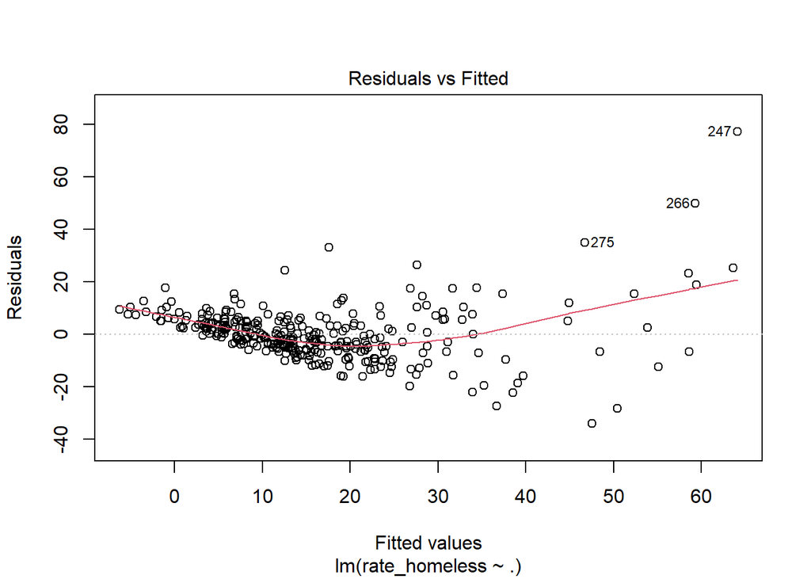

```r
plot(fit_all, 1)
```

The residual model has a systemic pattern where many more data points are clustered on the left. The linear regression with all variables is not the best model to fit the data.

#### Assess the model on the testing data

$\rightarrow$ Use the model to predict the homeless rate in the testing data.

```r
lm_predict <- predict(fit_all, df_test)
```

$\rightarrow$ Make a scatter plot to compare the actual value and the predicted value of `rate_homeless`.

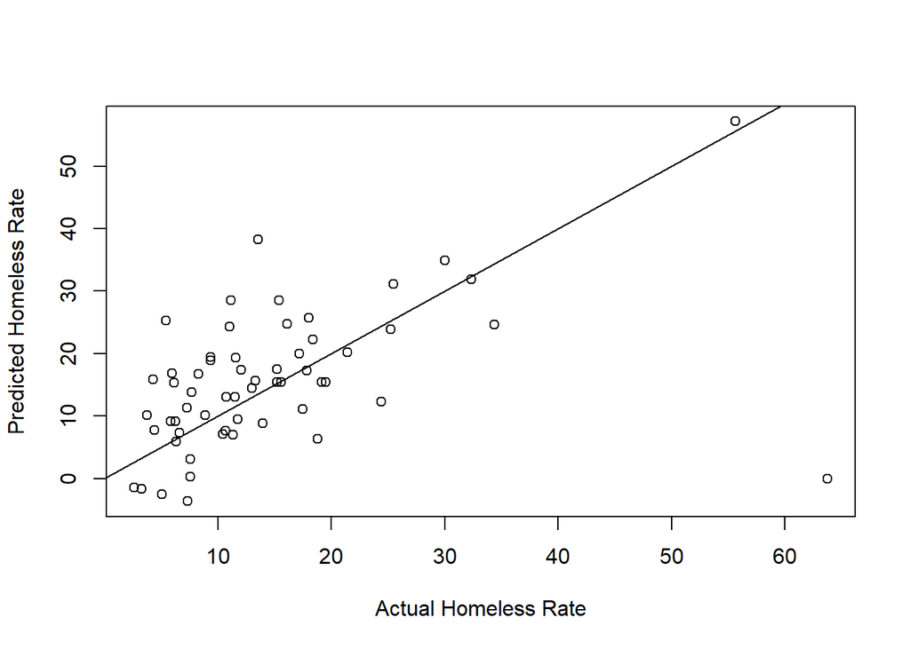

```r
plot(df_test$rate_homeless, lm_predict, xlab = "Actual Homeless Rate", ylab = "Predicted Homeless Rate")
abline(0, 1)
```

The graph shows that the linear model with all the variables predicts the homeless rate fairly well for lower rates, though the model tends to overestimate the rates. At high actual homeless rates, there is one point that is predicted to be much lower.

$\rightarrow$ Compute the RMSE

```r
rmse <- (df_test$rate_homeless - lm_predict)^2 %>%
  mean() %>%
  sqrt()
rmse
```

```
## [1] 11.46046
```

The RMSE is 11.46.

$\rightarrow$ Repeat the regression analysis, but using a different random seed before the train-test split. Does the train-test split affect the significance of the coefficients and their values?

```r
# Set seed to 10
set.seed(10)

# Split data
split_10 <- initial_split(df_2017, prop = 0.85, strata = rate_homeless)

# Get train and test split
df_train_10 <- training(split_10)
df_test_10 <- testing(split_10)

# Fit multiple linear regression
fit_10 <- lm(rate_homeless ~ ., data = df_train_10)
summary(fit_10)
```

```
##
## Call:
## lm(formula = rate_homeless ~ ., data = df_train_10)
##
## Residuals:
##     Min      1Q  Median      3Q     Max
## -33.548  -5.340  -0.836   4.478  78.552
##
## Coefficients:
##                                              Estimate Std. Error t value
## (Intercept)                                -6.530e+00  7.262e+01  -0.090
## house_price_index_2009                      5.746e-02  7.132e-02   0.806
## log_median_rent                             2.260e+01  8.401e+00   2.690
## utility_costs                              -4.671e-01  3.553e-01  -1.315
## percentage_owners_cost_burden_2016         -1.970e-01  5.027e-01  -0.392
## percentage_renters_severe_cost_burden_2016  8.958e-02  2.857e-01   0.314
## share_renters_2016                          1.196e-01  2.229e-01   0.536
## rental_vacancy_rate                        -4.152e-01  3.245e-01  -1.280
## high_housing_density                       -2.840e+00  2.260e+00  -1.257
## number_eviction                             3.028e-04  1.806e-04   1.677
## share_overcrowded_units_2016                1.553e+00  9.286e-01   1.673
## city_or_urban                              -1.127e+00  2.425e+00  -0.465
## suburban                                   -4.416e+00  2.271e+00  -1.945
## rate_unemployment                           1.463e+00  5.638e-01   2.595
## gini_coefficient_2016                      -5.642e-02  5.044e-01  -0.112
## poverty_rate                               -5.327e-01  5.155e-01  -1.034
## share_HUD_units                             1.753e+00  7.189e-01   2.438
## HUD_unit_occupancy_rate                    -2.758e-01  1.679e-01  -1.643
## share_built_before_1940                     4.575e-02  1.259e-01   0.363
## net_migration                              -6.503e-05  7.949e-05  -0.818
## migration_4_year_change                     3.701e+00  1.255e+00   2.948
## proportion_one_person_households            1.426e+00  4.023e-01   3.545
## share_under_18_with_single_parent           4.032e-01  3.271e-01   1.233
## share_veteran_status                       -4.115e-02  4.015e-01  -0.102
## share_no_bachelors                          4.520e-03  2.198e-01   0.021
## medicare_reimbursements_per_enrollee       -8.958e-02  8.928e-01  -0.100
## percentage_excessive_drinking              -6.136e+00  3.516e+01  -0.175
## average_Jan_temperature                     1.863e-01  1.736e-01   1.073
## average_summer_temperature                 -6.684e-02  2.903e-01  -0.230
## total_Jan_precipitation                     9.442e-01  2.343e-01   4.029
```

[output cut: 38 more lines]

```
## total_Jan_precipitation                    7.23e-05 ***
## total_annual_precipitation                  0.44183
## percent_black                               0.02343 *
## percent_asian                               0.05508 .
## percent_latino_hispanic                     0.56718
## percent_pacific_islander                    0.00845 **
## percent_0_19                                0.49904
## percent_65_plus                             0.78363
## percent_female                              0.25633
## ---
## Signif. codes:  0 '***' 0.001 '**' 0.01 '*' 0.05 '.' 0.1 ' ' 1
##
## Residual standard error: 10.86 on 278 degrees of freedom
## Multiple R-squared:  0.5842, Adjusted R-squared:  0.5289
## F-statistic: 10.56 on 37 and 278 DF,  p-value: < 2.2e-16
```

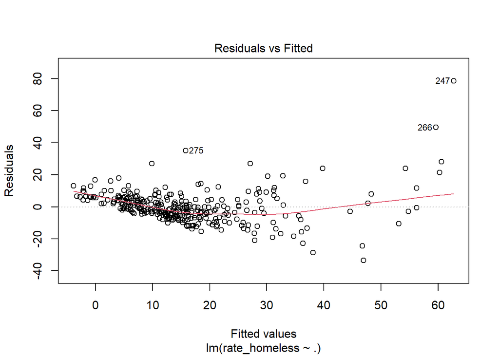

```r
# Graph residuals
plot(fit_10, 1)
```

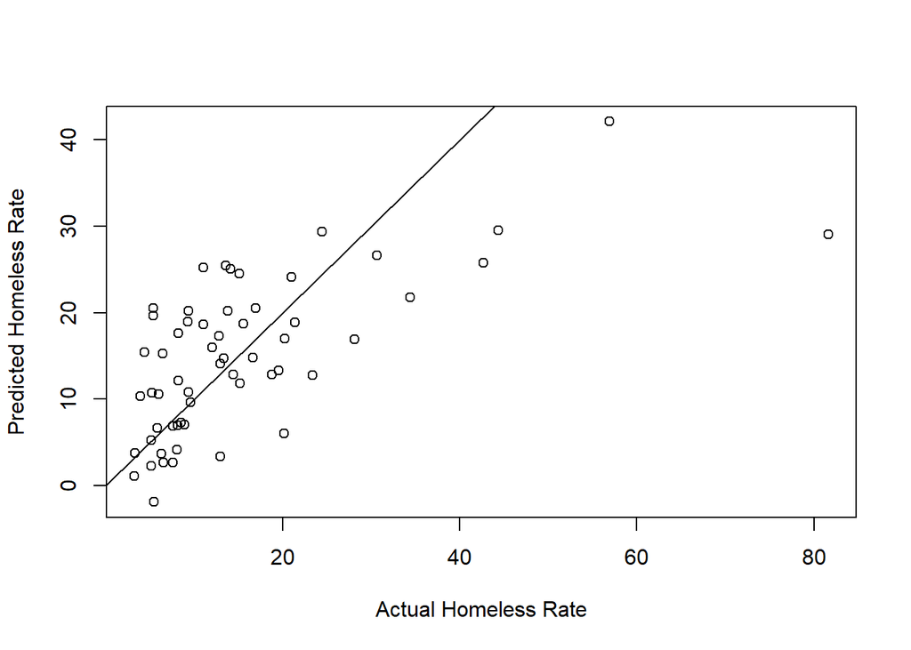

```r
# Predict for testing data,
predict_10 <- predict(fit_10, df_test_10)
plot(df_test_10$rate_homeless, predict_10, xlab = "Actual Homeless Rate", ylab = "Predicted Homeless Rate")
abline(0, 1)
```

The residual graph is similar to the residual graph from the first seed. The points continue to be systemically structured in a curve. The actual vs predicted graph is also similar, except for the points with high actual homeless rates. The coefficients are different, and give different significant predictor variables. When the seed was 20, migration_4_year_change, log_median_rent, and total_Jan_precipitation had the smallest p-values. When the seed was 10, total_Jan_precipitation and proportion_one_person_households had the smallest p-values.

### Subset selection

The full model contains too many predictors, so we will use subset selection on the training data to find a smaller number of predictors.

$\rightarrow$ Get the number of variables in the data set that will be used as predictors. This will be used to set the subset size.

```r
n <- ncol(df_train) - 1
n
```

```
## [1] 37
```

There are 37 variables in the data set that will be used as predictors.

$\rightarrow$ Do best subset selection on the training data. Set the maximum number of variables to equal the number of predictor variables in the data set.

```r
regfit_all <- regsubsets(rate_homeless ~ ., data = df_train, nvmax = n)
```

$\rightarrow$ Get the summary. We will use this after performing cross validation to determine the best model.

```r
regfit_summary <- summary(regfit_all)
```

#### Cross validation

$\rightarrow$ Use 10-fold cross validation on the training data to determine the best subset of predictors in the model.

```r
# Set number of observations (rows)
row <- nrow(df_train)

# Set number of folds
num_fold <- 10

# Set seed
set.seed(1)


folds <- sample(1:num_fold, row, replace = TRUE)
error <- matrix(NA, num_fold, n, dimnames = list(NULL, paste(1:n)))

for (i in 1:num_fold) {
  reg_fit_best <- regsubsets(rate_homeless ~ ., data = df_train[folds != i,], nvmax = n)
  test_mat <- model.matrix(rate_homeless ~ ., data = df_train[folds == i,])
  for (j in 1:n) {
    c <- coef(reg_fit_best, id = j)
    p <- test_mat[,names(c)] %*% c
    error[i, j] <- mean((df_train$rate_homeless[folds == i] - p)^2)
  }
}

error_mean <- apply(error, 2, mean)
```

$\rightarrow$ Plot the assessment measures vs. the number of predictors

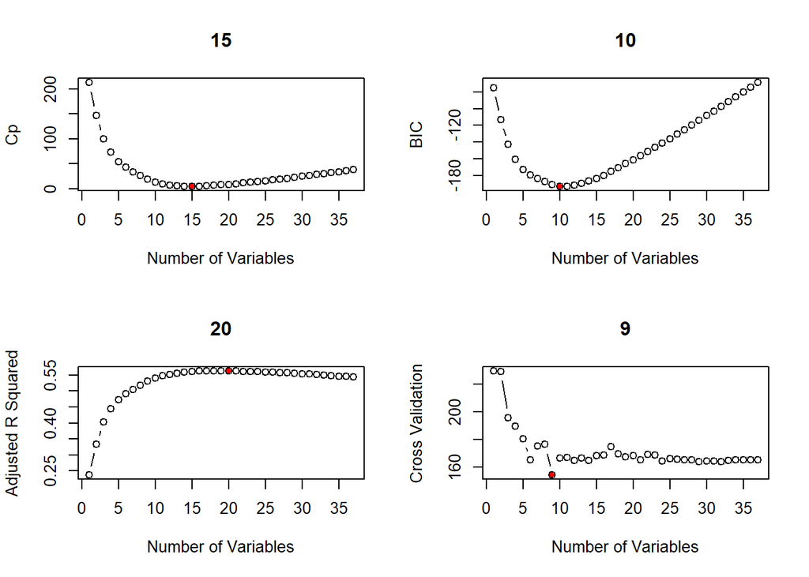

```r
# Set up 2x2 graphs
par(mfrow = c(2, 2))

# Find number of variables for minimum cp
# Sometimes this changes?
ind_cp <- which.min(regfit_summary$cp)
# Plot graph, title with number of variables
plot(regfit_summary$cp, type = "b", xlab = "Number of Variables", ylab = "Cp", main = toString(ind_cp))
# Color minimum point red
points(ind_cp, regfit_summary$cp[ind_cp], col = "red", pch = 20)

# Find number of variables for minimum bic
ind_bic = which.min(regfit_summary$bic)
# Plot graph, title with number of variables
plot(regfit_summary$bic, type = "b", xlab = "Number of Variables", ylab = "BIC", main = toString(ind_bic))
# Color minimum point red
points(ind_bic, regfit_summary$bic[ind_bic], col = "red", pch = 20)

# Find number of variables for maximum adjusted r squared
ind_adjr2 = which.max(regfit_summary$adjr2)
# Plot graph, title with number of variables
plot(regfit_summary$adjr2, type = "b", xlab = "Number of Variables", ylab = "Adjusted R Squared", main = toString(ind_adjr2))
# Color maximum point red
points(ind_adjr2, regfit_summary$adjr2[ind_adjr2], col = "red", pch = 20)

# Find number of variables to minimize mean error
ind_cv <- which.min(error_mean)
# Plot graph
plot(error_mean, type = "b", xlab = "Number of Variables", ylab = "Cross Validation", main = toString(ind_cv))
# Color minimum point red
points(ind_cv, error_mean[ind_cv], col = "red", pch = 20)
```

Each measure has a different number of variables. Minimizing the Cp has 15 variables, minimizing the BIC has 10 variables, maximizing the adjusted R squared has 20 variables, and minimizing the mean error has 9 variables.

$\rightarrow$ What are the coefficients of the best model according to different measures?

```r
# Cp coefficients
coef(regfit_all, ind_cp) %>%
  round(2) %>%
  data.frame()
```

```
##                                          .
## (Intercept)                        -140.81
## log_median_rent                      31.22
## percentage_owners_cost_burden_2016   -0.56
## high_housing_density                 -4.08
## share_overcrowded_units_2016          2.29
## suburban                             -3.51
## rate_unemployment                    -1.08
## share_HUD_units                       2.36
## migration_4_year_change               3.55
## proportion_one_person_households      1.73
## share_no_bachelors                    0.44
## percentage_excessive_drinking        52.57
## total_Jan_precipitation               1.09
## total_annual_precipitation            0.11
## percent_black                       -21.39
## percent_pacific_islander            211.57
```

```r
# BIC coefficients
coef(regfit_all, ind_bic) %>%
  round(2) %>%
  data.frame()
```

```
##                                        .
## (Intercept)                      -123.86
## log_median_rent                    26.78
## share_overcrowded_units_2016        1.49
## suburban                           -4.31
## share_HUD_units                     2.04
## migration_4_year_change             3.79
## proportion_one_person_households    1.80
## share_no_bachelors                  0.34
## total_Jan_precipitation             1.12
## percent_black                     -27.04
## percent_pacific_islander          247.62
```

The coefficients of the BIC model are close to those of the full linear model. The coefficient of share_HUD_units is the same in both cases: 2.04.

```r
# Adjusted r squared coefficients
coef(regfit_all, ind_adjr2) %>%
  round(2) %>%
  data.frame()
```

```
##                                         .
## (Intercept)                        -49.09
## house_price_index_2009               0.12
## log_median_rent                     28.58
## high_housing_density                -4.05
## number_eviction                      0.00
## share_overcrowded_units_2016         2.24
## suburban                            -3.48
## rate_unemployment                   -0.98
## share_HUD_units                      2.22
## net_migration                        0.00
## migration_4_year_change              3.88
## proportion_one_person_households     1.47
## share_under_18_with_single_parent    0.43
## share_no_bachelors                   0.16
## total_Jan_precipitation              1.04
## total_annual_precipitation           0.10
## percent_black                      -37.56
## percent_asian                      -42.42
## percent_latino_hispanic            -10.72
## percent_pacific_islander           292.97
## percent_female                    -128.02
```

The coefficients of the adjusted r squared model are similar to those of the full linear model. They all have the same signs and similar magnitudes.

```r
# Cv coefficients
coef(regfit_all, ind_cv) %>%
  round(2) %>%
  data.frame()
```

```
##                                       .
## (Intercept)                      -89.08
## log_median_rent                   17.73
## high_housing_density              -5.85
## share_overcrowded_units_2016       2.62
## share_HUD_units                    1.95
## migration_4_year_change            3.87
## proportion_one_person_households   1.91
## total_Jan_precipitation            1.13
## percent_black                    -20.89
## percent_pacific_islander         258.90
```

Most of the coefficients are of the same sign and magnitude as the full model. The biggest difference is the demographic variable percent_black. In the full model, it had a coefficient of -39.48. Here, the coefficient is -20.89, which is around half. None of the predictor values had drastic differences.

#### Assess the performance of the model on the testing data

Use the model to predict the homeless rate in the testing data. We will use the best BIC model as an example, but you should compare the performance of all models.

##### Cp Model Analysis

```r
# Select best variable subset from Cp analysis
df_cp <- df_train %>%
  select(all_of(names(coef(regfit_all, ind_cp))[2:length(coef(regfit_all, ind_cp))]), "rate_homeless")

# Fit linear regression model from subset
lm_cp <- lm(rate_homeless ~ ., data = df_cp)
summary(lm_cp)
```

```
##
## Call:
## lm(formula = rate_homeless ~ ., data = df_cp)
##
## Residuals:
##     Min      1Q  Median      3Q     Max
## -37.010  -5.292  -0.832   4.409  75.744
##
## Coefficients:
##                                      Estimate Std. Error t value Pr(>|t|)
## (Intercept)                        -140.81196   16.93080  -8.317 3.20e-15 ***
## log_median_rent                      31.21890    5.58803   5.587 5.19e-08 ***
## percentage_owners_cost_burden_2016   -0.55833    0.36948  -1.511 0.131805
## high_housing_density                 -4.08090    1.90765  -2.139 0.033225 *
## share_overcrowded_units_2016          2.29351    0.50760   4.518 8.97e-06 ***
## suburban                             -3.50865    1.46405  -2.397 0.017163 *
## rate_unemployment                    -1.07688    0.68008  -1.583 0.114368
## share_HUD_units                       2.36024    0.46567   5.068 7.03e-07 ***
## migration_4_year_change               3.55113    1.06567   3.332 0.000969 ***
## proportion_one_person_households      1.73249    0.21122   8.203 6.98e-15 ***
## share_no_bachelors                    0.43501    0.12090   3.598 0.000375 ***
## percentage_excessive_drinking        52.57429   26.45736   1.987 0.047817 *
## total_Jan_precipitation               1.09176    0.20210   5.402 1.34e-07 ***
## total_annual_precipitation            0.10597    0.05479   1.934 0.054035 .
## percent_black                       -21.39364    6.73130  -3.178 0.001636 **
## percent_pacific_islander            211.56708   83.10228   2.546 0.011401 *
## ---
## Signif. codes:  0 '***' 0.001 '**' 0.01 '*' 0.05 '.' 0.1 ' ' 1
##
## Residual standard error: 10.72 on 300 degrees of freedom
## Multiple R-squared:  0.5821, Adjusted R-squared:  0.5613
## F-statistic: 27.86 on 15 and 300 DF,  p-value: < 2.2e-16
```

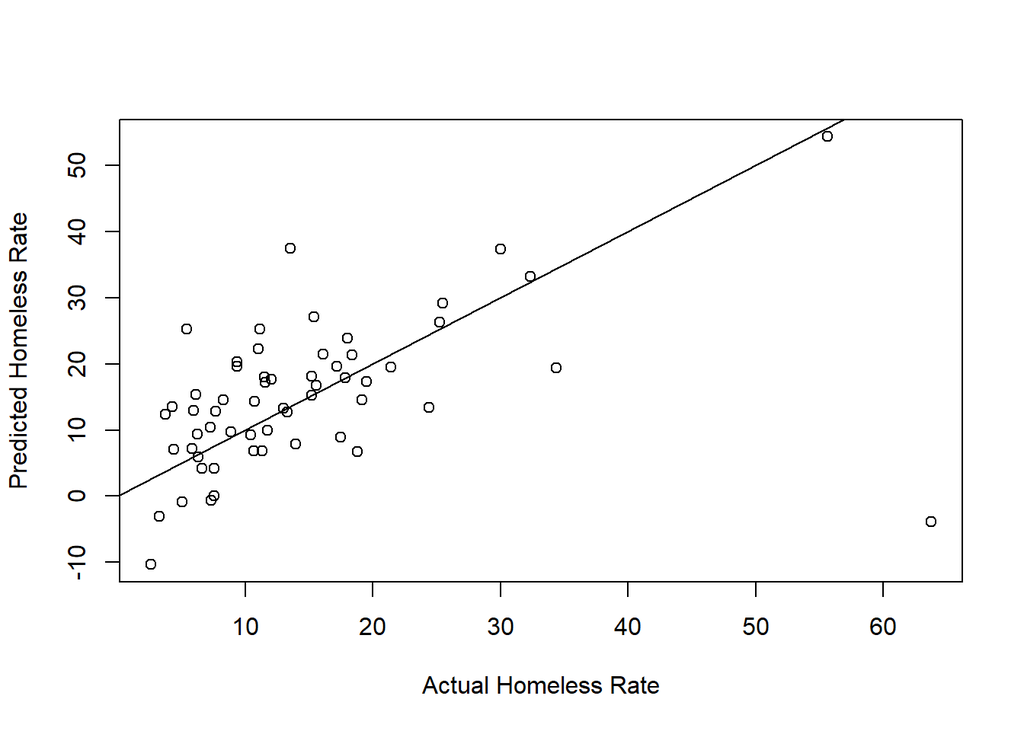

```r
# Predict homeless rate from model
pred_cp <- predict(lm_cp, df_test)

# Plot actual vs predicted homeless rate
plot(df_test$rate_homeless, pred_cp, xlab = "Actual Homeless Rate", ylab = "Predicted Homeless Rate")
# Add x = y line
abline(0, 1)
```

```r
# Calculate RMSE
rmse_cp <- (df_test$rate_homeless - pred_cp)^2 %>%
  mean() %>%
  sqrt()
rmse_cp
```

```
## [1] 11.70967
```

Not all of the variables are significant. At the 0.05 level, high_housing_density, share_overcrowded_units_2016, suburban, share_HUD_units, migration_4_year_change, proportion_one_person_households, share_no_bachelors, percentage_excessive_drinking, and total_Jan_precipitation are significant. The model also includes demographic variables. In the actual vs predicted homeless rate model, the predicted values are higher than the actual values. The RMSE is 11.71. It’s close to, but slightly larger than the RMSE of the full model (11.46).

##### BIC Model Analysis

```r
# Select subset of variables from best subset selection
df_bic <- df_train %>%
  select(all_of(names(coef(regfit_all, ind_bic))[2:length(coef(regfit_all, ind_bic))]), "rate_homeless")

# Fit model from subset
lm_bic <- lm(rate_homeless ~ ., data = df_bic)
summary(lm_bic)
```

```
##
## Call:
## lm(formula = rate_homeless ~ ., data = df_bic)
##
## Residuals:
##     Min      1Q  Median      3Q     Max
## -36.546  -4.824  -1.366   4.441  79.701
##
## Coefficients:
##                                   Estimate Std. Error t value Pr(>|t|)
## (Intercept)                      -123.8573    15.5886  -7.945 3.77e-14 ***
## log_median_rent                    26.7838     3.9648   6.755 7.22e-11 ***
## share_overcrowded_units_2016        1.4937     0.4581   3.261 0.001238 **
## suburban                           -4.3119     1.4781  -2.917 0.003793 **
## share_HUD_units                     2.0380     0.4553   4.477 1.07e-05 ***
## migration_4_year_change             3.7909     1.0552   3.593 0.000381 ***
## proportion_one_person_households    1.8011     0.2065   8.721  < 2e-16 ***
## share_no_bachelors                  0.3420     0.1015   3.370 0.000848 ***
## total_Jan_precipitation             1.1238     0.1894   5.934 8.04e-09 ***
## percent_black                     -27.0435     5.9002  -4.584 6.68e-06 ***
## percent_pacific_islander          247.6198    82.7792   2.991 0.003004 **
## ---
## Signif. codes:  0 '***' 0.001 '**' 0.01 '*' 0.05 '.' 0.1 ' ' 1
##
## Residual standard error: 10.96 on 305 degrees of freedom
## Multiple R-squared:  0.5559, Adjusted R-squared:  0.5414
## F-statistic: 38.18 on 10 and 305 DF,  p-value: < 2.2e-16
```

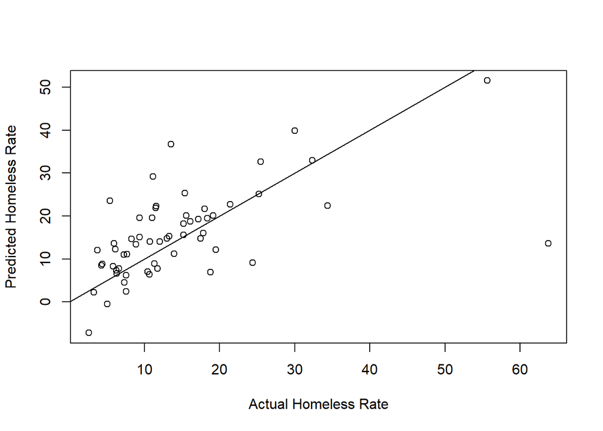

```r
# Predict rate_homeless from model
pred_bic <- predict(lm_bic, df_test)

# Plot actual vs predicted omeless rate
plot(df_test$rate_homeless, pred_bic, xlab = "Actual Homeless Rate", ylab = "Predicted Homeless Rate")
# Add x = y line
abline(0, 1)
```

```r
# Calculate RMSE
rmse_bic <- (df_test$rate_homeless - pred_bic)^2 %>%
  mean() %>%
  sqrt()
rmse_bic
```

```
## [1] 9.817378
```

All the variables included in the model are significant at the 0.01 level. In the actual vs predicted homeless rate graph, most of the points are clustered about the x = y line, so the model predicts higher values for the homeless rate than they actually are. The RMSE is 9.82, which is lower than the RMSE for the full model. The BIC model is a better fit than the full model.

##### Adjusted R Squared Model Analysis

```r
# Select best variables from adjusted R square analysis
df_adjr2 <- df_train %>%
  select(all_of(names(coef(regfit_all, ind_adjr2))[2:length(coef(regfit_all, ind_adjr2))]), "rate_homeless")

# Fit model with data subset
lm_adjr2 <- lm(rate_homeless ~ ., data = df_adjr2)
summary(lm_adjr2)
```

```
##
## Call:
## lm(formula = rate_homeless ~ ., data = df_adjr2)
##
## Residuals:
##     Min      1Q  Median      3Q     Max
## -36.008  -5.380  -0.368   4.762  77.706
##
## Coefficients:
##                                     Estimate Std. Error t value Pr(>|t|)
## (Intercept)                       -4.909e+01  4.964e+01  -0.989 0.323494
## house_price_index_2009             1.225e-01  5.606e-02   2.185 0.029675 *
## log_median_rent                    2.858e+01  4.167e+00   6.860 4.05e-11 ***
## high_housing_density              -4.054e+00  1.991e+00  -2.036 0.042660 *
## number_eviction                    2.012e-04  1.595e-04   1.262 0.208091
## share_overcrowded_units_2016       2.240e+00  7.111e-01   3.151 0.001796 **
## suburban                          -3.481e+00  1.546e+00  -2.252 0.025038 *
## rate_unemployment                 -9.813e-01  6.891e-01  -1.424 0.155472
## share_HUD_units                    2.216e+00  5.193e-01   4.266 2.68e-05 ***
## net_migration                     -1.042e-04  7.283e-05  -1.431 0.153378
## migration_4_year_change            3.880e+00  1.119e+00   3.466 0.000606 ***
## proportion_one_person_households   1.470e+00  2.620e-01   5.609 4.69e-08 ***
## share_under_18_with_single_parent  4.298e-01  2.812e-01   1.528 0.127524
## share_no_bachelors                 1.578e-01  1.331e-01   1.186 0.236572
## total_Jan_precipitation            1.035e+00  2.079e-01   4.981 1.08e-06 ***
## total_annual_precipitation         1.018e-01  5.607e-02   1.815 0.070506 .
## percent_black                     -3.756e+01  1.214e+01  -3.093 0.002168 **
## percent_asian                     -4.242e+01  2.024e+01  -2.096 0.036941 *
## percent_latino_hispanic           -1.072e+01  9.831e+00  -1.091 0.276233
## percent_pacific_islander           2.930e+02  1.015e+02   2.887 0.004171 **
## percent_female                    -1.280e+02  8.601e+01  -1.488 0.137721
## ---
## Signif. codes:  0 '***' 0.001 '**' 0.01 '*' 0.05 '.' 0.1 ' ' 1
##
## Residual standard error: 10.7 on 295 degrees of freedom
## Multiple R-squared:  0.5907, Adjusted R-squared:  0.563
## F-statistic: 21.29 on 20 and 295 DF,  p-value: < 2.2e-16
```

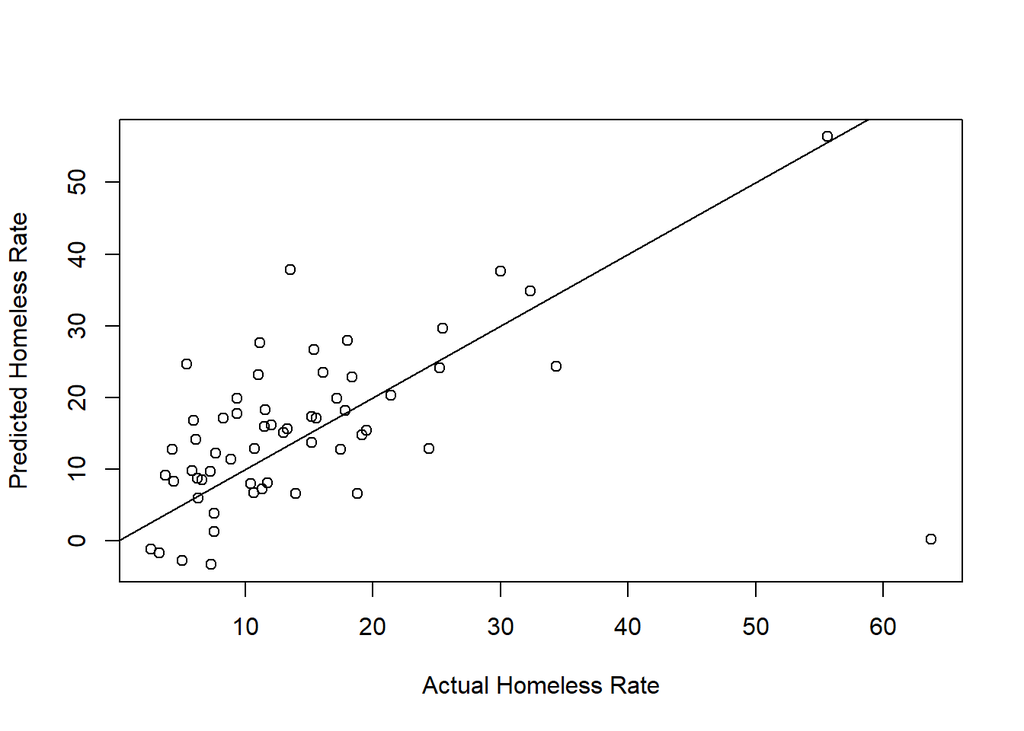

```r
# Predict homeless rate
pred_adjr2 <- predict(lm_adjr2, df_test)

# Plot measured vs predicted values for rate_homeless
plot(df_test$rate_homeless, pred_adjr2, xlab = "Actual Homeless Rate", ylab = "Predicted Homeless Rate")
# Add x = y line
abline(0, 1)
```

```r
# Calculate RMSE
rmse_adjr2 <- (df_test$rate_homeless - pred_adjr2)^2 %>%
  mean() %>%
  sqrt()
rmse_adjr2
```

```
## [1] 11.24978
```

Not all variables are significant. At the 0.05 level, share_overcrowded_units_2016, suburban, share_HUD_units, migration_4_year_change, proportion_one_person_households, and total_Jan_precipitation are significant. Comparing the actual and predicted values shows that the homeless rate is predicted higher than it actually is. The RMSE is 11.25. It is similar to the RMSE for the full model.

##### CV Model Analysis

```r
# Select best variables from CV analysis
df_cv <- df_train %>%
  select(all_of(names(coef(regfit_all, ind_cv))[2:length(coef(regfit_all, ind_cv))]), "rate_homeless")

# Fit model with data subset
lm_cv <- lm(rate_homeless ~ ., data = df_cv)
summary(lm_cv)
```

```
##
## Call:
## lm(formula = rate_homeless ~ ., data = df_cv)
##
## Residuals:
##     Min      1Q  Median      3Q     Max
## -38.484  -5.074  -0.810   4.465  82.115
##
## Coefficients:
##                                  Estimate Std. Error t value Pr(>|t|)
## (Intercept)                      -89.0815     8.0676 -11.042  < 2e-16 ***
## log_median_rent                   17.7267     2.6205   6.765 6.80e-11 ***
## high_housing_density              -5.8501     1.8567  -3.151 0.001789 **
## share_overcrowded_units_2016       2.6187     0.4030   6.498 3.31e-10 ***
## share_HUD_units                    1.9541     0.4573   4.273 2.57e-05 ***
## migration_4_year_change            3.8704     1.0303   3.757 0.000206 ***
## proportion_one_person_households   1.9130     0.1972   9.700  < 2e-16 ***
## total_Jan_precipitation            1.1251     0.1920   5.861 1.19e-08 ***
## percent_black                    -20.8918     6.1061  -3.421 0.000708 ***
## percent_pacific_islander         258.8959    83.4941   3.101 0.002110 **
## ---
## Signif. codes:  0 '***' 0.001 '**' 0.01 '*' 0.05 '.' 0.1 ' ' 1
##
## Residual standard error: 11.08 on 306 degrees of freedom
## Multiple R-squared:  0.5443, Adjusted R-squared:  0.5309
## F-statistic: 40.61 on 9 and 306 DF,  p-value: < 2.2e-16
```

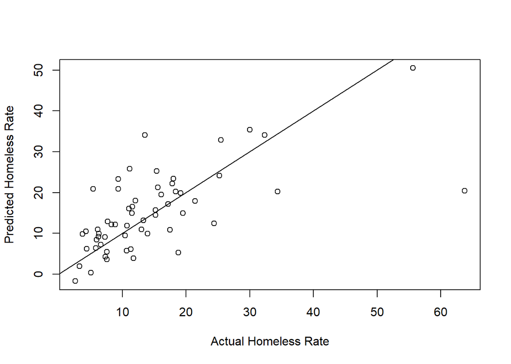

```r
# Predict homeless rate
pred_cv <- predict(lm_cv, df_test)

# Plot measured vs predicted values for rate_homeless
plot(df_test$rate_homeless, pred_cv, xlab = "Actual Homeless Rate", ylab = "Predicted Homeless Rate")
# Add x = y line
abline(0, 1)
```

```r
# Calculate RMSE
rmse_cv <- (df_test$rate_homeless - pred_cv)^2 %>%
  mean() %>%
  sqrt()
rmse_cv
```

```
## [1] 8.794606
```

All the included variables are significant. The actual vs predicted graph is even for lower homeless rates, and differs for higher rates. The RMSE is 8.79, which is the lowest value for the subset selections.

### Lasso

The lasso is another approach to producing a linear regression model with a subset of the available predictors. The lasso works by finding coefficients $\boldsymbol{\beta}$ that minimize the cost function:

$$C(\boldsymbol{\beta}) = \sum_{i=1}^n(y_i
- \beta_{0} - \sum_{j=1}^p\beta_{j}x_{ij})^2 + \lambda
\sum_{j=1}^p|\beta_{j}| = \text{RSS} + \lambda
\sum_{j=1}^p|\beta_{j}|$$

where $\lambda \geq 0$ is a tuning parameter (or hyperparameter).

$\rightarrow$ Prepare the data by creating a model matrix `x_train` from the training data. Create the model matrix using `model.matrix` so that it includes the training data for all predictors, but does not include a column for the intercept. Also create the training response data `y_train`.

```r
# Create model matrix, remove intercept
x_train <- model.matrix(rate_homeless ~ ., df_train)[,-1]
# Create training response
y_train <- df_train$rate_homeless
```

$\rightarrow$ Use cross-validation to find the best hyperparameter $\lambda$

```r
lasso_cv <- cv.glmnet(x_train, y_train, alpha = 1)
```

$\rightarrow$ Show error as a function of the hyperparameter $\lambda$ and its best value.

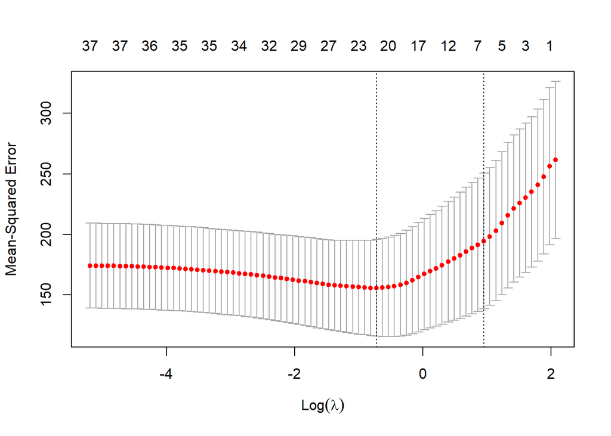

```r
plot(lasso_cv)
```

```r
lasso_best_lam <- lasso_cv$lambda.1se
lasso_best_lam
```

```
## [1] 2.588168
```

From the graph, the minimum lambda is a model with 20-23 variables, and the one standard error lambda is a model with 7 variables. I chose to use the one standard error as my lambda: 2.59.

$\rightarrow$ Fit the lasso with the best $\lambda$ using the function `glmnet`.

```r
lasso_mod <- glmnet(x_train, y_train, alpha = 1, lambda = lasso_best_lam)
```

$\rightarrow$ Examine the coefficients. Which variables have non-zero coefficients?

```r
coef(lasso_mod)
```

```
## 38 x 1 sparse Matrix of class "dgCMatrix"
##                                                     s0
## (Intercept)                                 15.3656329
## house_price_index_2009                       .
## log_median_rent                              .
## utility_costs                               -0.2690156
## percentage_owners_cost_burden_2016           .
## percentage_renters_severe_cost_burden_2016   .
## share_renters_2016                           0.4551854
## rental_vacancy_rate                          .
## high_housing_density                         .
## number_eviction                              .
## share_overcrowded_units_2016                 0.8701156
## city_or_urban                                .
## suburban                                     .
## rate_unemployment                            .
## gini_coefficient_2016                        .
## poverty_rate                                 .
## share_HUD_units                              .
## HUD_unit_occupancy_rate                      .
## share_built_before_1940                      .
## net_migration                                .
## migration_4_year_change                      .
## proportion_one_person_households             .
## share_under_18_with_single_parent            .
## share_veteran_status                         .
## share_no_bachelors                           .
## medicare_reimbursements_per_enrollee         .
## percentage_excessive_drinking                .
## average_Jan_temperature                      .
## average_summer_temperature                   .
## total_Jan_precipitation                      0.5819177
## total_annual_precipitation                   .
## percent_black                                .
## percent_asian                                .
## percent_latino_hispanic                      .
## percent_pacific_islander                    19.9992706
## percent_0_19                               -64.2559600
## percent_65_plus                              .
## percent_female                               .
```

The predictor variables with non-zero coefficients are utility_costs, share_renters_2016, share_overcrowded_units_2016, and total_Jan_precipitation. Demographic variables percent_pacific_island and percent_0_19 also have non-zero coefficients.

#### Look at prediction error

$\rightarrow$ Use the model to predict the homeless rate in the testing data.

```r
x_test <- model.matrix(rate_homeless ~ ., df_test)[,-1]
lasso_predict <- predict(lasso_mod, s = lasso_best_lam, newx = x_test)
```

$\rightarrow$ Make a scatter plot to compare the actual value and the predicted value of `rate_homeless`.

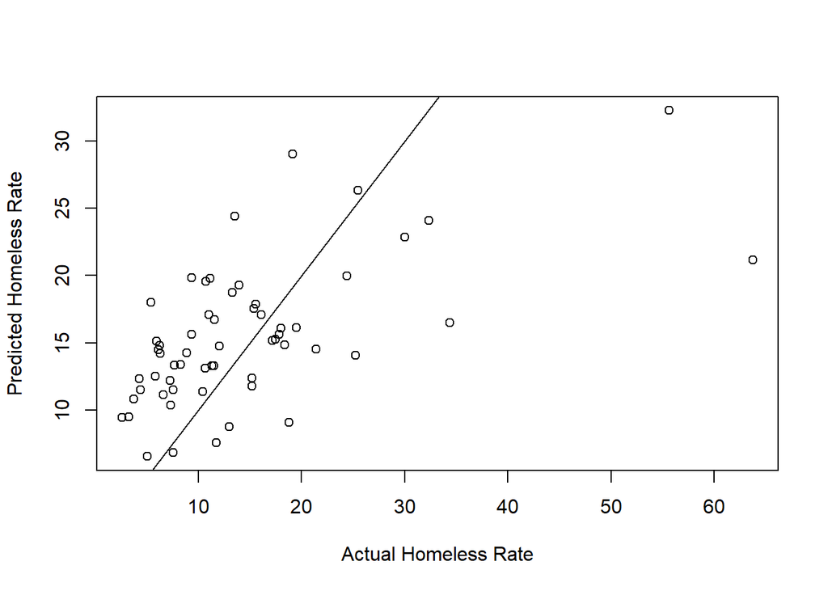

```r
plot(df_test$rate_homeless, lasso_predict, xlab = "Actual Homeless Rate", ylab = "Predicted Homeless Rate")
abline(0, 1)
```

The predictions are fairly accurate for lower homeless rates. The model tends to overestimate the rate for lower actual homeless rates. At higher actual homeless rates, the model underestimates the rate.

$\rightarrow$ Compute the RMSE. How does it compare to the other models?

```r
lasso_rmse <- (df_test$rate_homeless - lasso_predict)^2 %>%
  mean() %>%
  sqrt()
lasso_rmse
```

```
## [1] 9.061881
```

The RMSE is 9.06.

### Ridge regression

Ridge regression is another approach to model building

Ridge regression works by finding coefficients $\boldsymbol{\beta}$ that minimize the cost function:

$$C(\boldsymbol{\beta}) = \sum_{i=1}^n(y_i
- \beta_{0} - \sum_{j=1}^p\beta_{j}x_{ij})^2 + \lambda
\sum_{j=1}^p\beta_{j}^2 = \text{RSS} + \lambda
\sum_{j=1}^p\beta_{j}^2$$

In contrast to the lasso, ridge regression will not reduce the number of non-zero coefficients in the model. Ridge regression will shrink the coefficients, which helps to prevent overfitting of the training data.

The fitting procedure for the ridge regression model mirrors the lasso approach, only changing the parameter $\alpha$ to 0 in the `cv.glmnet` and `glmnet` functions.

$\rightarrow$ Fit and assess a ridge regression model. How does it compare to the other models?

```r
# Perform ridge cross validation
ridge_cv <- cv.glmnet(x_train, y_train, alpha = 0)

# Find best lambda
ridge_best_lam <- ridge_cv$lambda.1se
ridge_best_lam
```

```
## [1] 68.74403
```

The best lambda value is 68.74. I used the one standard error lambda for the ridge as well.

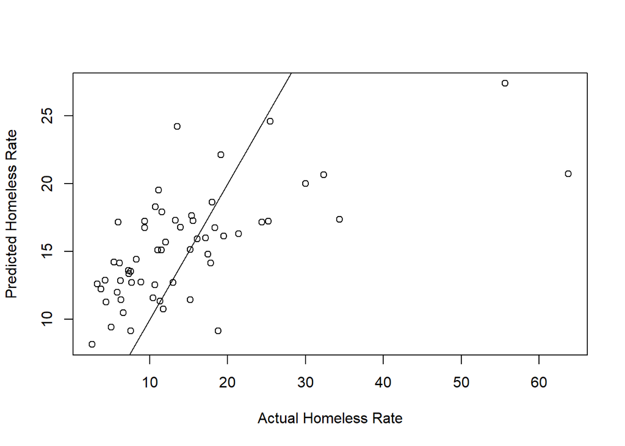

```r
# Fit model
ridge_mod <- glmnet(x_train, y_train, alpha = 0, lambda = ridge_best_lam)

# Predict values from model
ridge_predict <- predict(ridge_mod, s = ridge_best_lam, newx = x_test)

# Plot actual vs predicted values
plot(df_test$rate_homeless, ridge_predict, xlab = "Actual Homeless Rate", ylab = "Predicted Homeless Rate")
abline(0, 1)
```

The model overestimates the homeless rates for lower actual homeless rates, and underestimates it for higher actual homeless rates. A few of the points from the 10-20 range lie directly on the x = y line.

```r
# Calculate RMSE
ridge_rmse <- (df_test$rate_homeless - ridge_predict)^2 %>%
  mean() %>%
  sqrt()
ridge_rmse
```

```
## [1] 9.162319
```

The RMSE is 9.16. It is slightly greater, but close to the RMSE from the lasso model.

### XGBoost

XGBoost is short for eXtreme Gradient Boosting.

We are going to use the `tidymodels` package to fit the XGBoost model.

#### Set up the model

The model will be a boosted tree model, so we start by specifying the features of a `boost_tree` model. The`boost_tree` creates a specification of a model, but does not fit the model.

```r
xgb_spec <- boost_tree(
  mode = "regression",  #We are solving a regression problem
  trees = 1000,
  tree_depth = tune(),  # tune() says that we will specify this parameter later
  min_n = tune(),
  loss_reduction = tune(),
  sample_size = tune(),
  mtry = tune(),
  learn_rate = tune(),
  ) %>%
  set_engine("xgboost", objective = "reg:squarederror") ## We will use xgboost to fit the model and try to minimize the squared error

xgb_spec
```

```
## Boosted Tree Model Specification (regression)
##
## Main Arguments:
##   mtry = tune()
##   trees = 1000
##   min_n = tune()
##   tree_depth = tune()
##   learn_rate = tune()
##   loss_reduction = tune()
##   sample_size = tune()
##
## Engine-Specific Arguments:
##   objective = reg:squarederror
##
## Computational engine: xgboost
```

Create a workflow that specifies the model formula and the model type. We are still setting up the model; this does not fit the model.

```r
xgb_wf <- workflow() %>%
  add_formula(rate_homeless ~ .) %>%
  add_model(xgb_spec)

xgb_wf
```

```
## == Workflow ====================================================================
## Preprocessor: Formula
## Model: boost_tree()
##
## -- Preprocessor ----------------------------------------------------------------
## rate_homeless ~ .
##
## -- Model -----------------------------------------------------------------------
## Boosted Tree Model Specification (regression)
##
## Main Arguments:
##   mtry = tune()
##   trees = 1000
##   min_n = tune()
##   tree_depth = tune()
##   learn_rate = tune()
##   loss_reduction = tune()
##   sample_size = tune()
##
## Engine-Specific Arguments:
##   objective = reg:squarederror
##
## Computational engine: xgboost
```

#### Fit the model

We need to fit all of the parameters that we specified as `tune()`. We will specify the parameter grid using the functions `grid_latin_hypercube`:

```r
xgb_grid <- grid_latin_hypercube(
  tree_depth(),
  min_n(),
  loss_reduction(),
  sample_size = sample_prop(),
  finalize(mtry(), df_train),
  learn_rate(),
  size = 30  #Create 30 sets of the 6 parameters
)
```

Create folds for cross-validation.

```r
folds <- vfold_cv(df_train)
```

Do the parameter fitting. This will take some time.

```r
xgb_res <- tune_grid(
  xgb_wf,              #The workflow
  resamples = folds,   #The training data split into folds
  grid = xgb_grid,     #The grid of parameters to fit
  control = control_grid(save_pred = TRUE)
)
```

[output not shown]

[output not shown]

[output not shown]

[output not shown]

[output not shown]

[output not shown]

[output not shown]

[output not shown]

[output not shown]

[output not shown]

```r
xgb_res
```

```
## # Tuning results
## # 10-fold cross-validation
## # A tibble: 10 x 5
##    splits           id     .metrics           .notes           .predictions
##    <list>           <chr>  <list>             <list>           <list>
##  1 <split [284/32]> Fold01 <tibble [60 x 10]> <tibble [1 x 3]> <tibble>
##  2 <split [284/32]> Fold02 <tibble [60 x 10]> <tibble [1 x 3]> <tibble>
##  3 <split [284/32]> Fold03 <tibble [60 x 10]> <tibble [1 x 3]> <tibble>
##  4 <split [284/32]> Fold04 <tibble [60 x 10]> <tibble [1 x 3]> <tibble>
##  5 <split [284/32]> Fold05 <tibble [60 x 10]> <tibble [1 x 3]> <tibble>
##  6 <split [284/32]> Fold06 <tibble [60 x 10]> <tibble [1 x 3]> <tibble>
##  7 <split [285/31]> Fold07 <tibble [60 x 10]> <tibble [1 x 3]> <tibble>
##  8 <split [285/31]> Fold08 <tibble [60 x 10]> <tibble [1 x 3]> <tibble>
##  9 <split [285/31]> Fold09 <tibble [60 x 10]> <tibble [1 x 3]> <tibble>
## 10 <split [285/31]> Fold10 <tibble [60 x 10]> <tibble [1 x 3]> <tibble>
##
## There were issues with some computations:
##
##   - Warning(s) x10: A correlation computation is required, but `estimate` is constant...
##
## Use `collect_notes(object)` for more information.
```

Set up the final workflow with the best model parameters.

```r
#Get the best model, according to RMSE
best_rmse <- select_best(xgb_res, "rmse")

#Update the workflow with the best parameters
final_xgb <- finalize_workflow(
  xgb_wf,
  best_rmse
)

final_xgb
```

```
## == Workflow ====================================================================
## Preprocessor: Formula
## Model: boost_tree()
##
## -- Preprocessor ----------------------------------------------------------------
## rate_homeless ~ .
##
## -- Model -----------------------------------------------------------------------
## Boosted Tree Model Specification (regression)
##
## Main Arguments:
##   mtry = 7
##   trees = 1000
##   min_n = 3
##   tree_depth = 4
##   learn_rate = 0.0107153006007263
##   loss_reduction = 0.00168670164001662
##   sample_size = 0.60449863047339
##
## Engine-Specific Arguments:
##   objective = reg:squarederror
##
## Computational engine: xgboost
```

#### Prediction

Fit the final model to the training data and predict the test data.

```r
final_res <- last_fit(final_xgb, split)
```

Show the RMSE. Compare the result to the test RMSE for the other models.

```r
collect_metrics(final_res)
```

```
## # A tibble: 2 x 4
##   .metric .estimator .estimate .config
##   <chr>   <chr>          <dbl> <chr>
## 1 rmse    standard       9.15  Preprocessor1_Model1
## 2 rsq     standard       0.410 Preprocessor1_Model1
```

The RMSE is 9.15. It is similar to the RMSE from the lasso and ridge models.

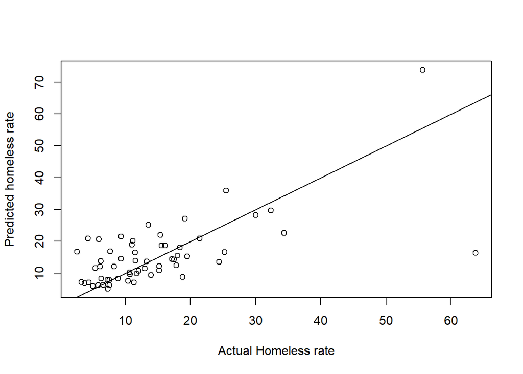

```r
plot(final_res$.predictions[[1]]$rate_homeless,final_res$.predictions[[1]]$.pred, xlab = "Actual Homeless rate", ylab = "Predicted homeless rate")
abline(0, 1)
```

The model is fairly accurate at predicting most of the actual homeless rates. The points are evenly divided around the x = y line. Only two points at higher homeless rates are off: one much higher than the line, and one much lower.

#### Relative importance of predictors

Look at which predictors are most important in the model

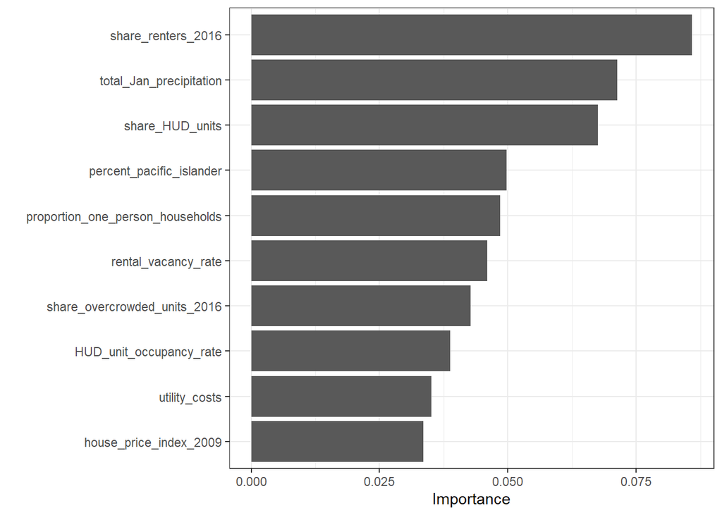

```r
final_xgb %>%
  fit(data = df_train) %>%
  extract_fit_parsnip() %>%
  vip(geom = "col")
```

The most important variable is share_renters_2016, fllowed by total_Jan_precipitation and share_HUD_units.

### Compare models

You used several methods to construct a model

1. Use statistical significance to create a multiple linear regression model.
2. Best subset selection for a multiple linear regression model.
3. Lasso
4. Ridge regression
5. XGBoost

Compare the performance of the models.

The full linear regression model has three most significant variables: log_median_rent, migration_4_year_change, and total_Jan_precipitation. The plot of the residuals has a systemic structure, where many of the points are clustered on the left in an almost parabolic shape. In the plot of actual vs predicted homeless rate, the lower rates are pretty evenly distributed around the x = y line. At higher actual homeless rates, the predictions are more off. The RMSE is 11.46.

The different linear regression subset selections have slightly different values for the RMSE, and similar actual vs predicted homeless rate graphs. The Cp model includes 15 variables, though not all of them are significant. The RMSE is 11.71, which is slightly higher than the RMSE of the full linear model. The BIC model has an RMSE of 9.82, and includes 10 significant variables. The adjusted r squared model has an RMSE of 11.25 and 20 variables. Not all of the variables in this model are significant. The cross validation model has 9 significant variables and an RMSE of 8.79, which the lowest RMSE from all the linear models.

In the ridge model, the RMSE is 9.16. Its predicted vs actual homeless rate plot looks similar to those of the linear and lasso regression models, though it has some points on the x = y line, unlike those models.

The tree model has an RMSE of 9.15, similar to the lasso and ridge models. The most important variables in this model are share_renters_2016, total_Jan_precipitation, share_HUD_units, proportion_one_person_households, and rental_vacancy_rate.

## Additional step

In addition to completing the above analyses, you should perform any revisions to the models that you think might improve their performance. Consult Canvas for further directions.

### Question

I chose to look at how the location may have an effect on the most significant variables. The original large data set has a variable for the four census regions (northeast, midwest, south, west), labelled from 1 to 4 in the same order as the US Census. I did a lasso regression analysis with the combination of the census region and the four predictor variables with non-zero coefficients from my original analysis. I chose to do a lasso analysis because it had the lowest RMSE from my initial analysis, though that has changed.

### Data Re-organization

```r
# Select variables from original lasso analysis and add census_region
var_region <- c("year",

  "pit_tot_hless_pit_hud", "dem_pop_pop_census",

  "hou_mkt_utility_xt", "hou_mkt_rentshare_acs5yr_2017", "hou_mkt_ovrcrowd_acs5yr_2017",

  "env_wea_precip_noaa",

  "census_region"
  )

# Filter original data set to data from variable list and 2017
df_region <- df %>%
  select(all_of(var_region)) %>%
  filter(year == 2017)
```

```r
# Rename variables to match rest of analysis
df_region <- df_region %>%
   rename(
total_homeless = "pit_tot_hless_pit_hud",
total_population = "dem_pop_pop_census",
total_Jan_precipitation = "env_wea_precip_noaa",
share_renters_2016 = "hou_mkt_rentshare_acs5yr_2017",
share_overcrowded_units_2016 = "hou_mkt_ovrcrowd_acs5yr_2017",
utility_costs  = "hou_mkt_utility_xt",
)

# Get rid of entries with missing total homeless entries
df_region <- df_region %>%
  filter(is.na(total_homeless) == FALSE)
```

```r
# Convert from total to rate, and change census_region to factor
df_region <- df_region %>%
  mutate(rate_homeless = total_homeless / (total_population / 10000)) %>%
  mutate(census_region = as.factor(census_region))
```

```r
set.seed(20)

# Split data again
split_region <- initial_split(df_region, prop = 0.85, strata = rate_homeless)

train_region <- training(split_region)
test_region <- testing(split_region)
```